# Phan tich mean 2 tay

Minh

2024-02-29

## Load bộ số liệu và các packages

## So sánh khác biệt về trung bình của chỉ số 2 tay theo các biến

Tạo biến M_tbinh = (M_right + M_left)/2 (vì số lần đo tay trái = số lần đo tay phải nên có thể tính trung bình như vậy)

Tạo hàm tính 95%CI

Tạo hàm so sánh trung bình bằng Wilcox.test nếu subgroup có 2 level

Tạo hàm so sánh bắt cặp các trung bình bằng Wilcox.pairwise test nếu group có >2 level

Tạo hàm vẽ Forest plot

Hàm để tạo bảng

Sub group list = “Gender”, “Smoking”, “Obesity”, “BMI25”, “Stress index”, “Typer of skins”, “Hypertension”, “Age_stage”

## Tạo bảng và Forest plot với biến M_tbinh

| Subgroup_Category | Subgroup | n_M_tbinh | Mean | CI_lower | CI_upper | P_Value |
| --- | --- | --- | --- | --- | --- | --- |
| Gender | 0 | 31 | 21.09450 | 17.871068 | 24.31794 | 0.2430600 |
| Gender | 1 | 44 | 23.17592 | 20.269833 | 26.08201 | 0.2430600 |
| Smoking | Do not smoke | 62 | 22.78524 | 20.506337 | 25.06414 | 0.8173597 |
| Smoking | Cigarettes, pipe tobacco… | 13 | 20.07579 | 13.706012 | 26.44558 | 0.8173597 |
| Obesity | 0 | 68 | 21.87394 | 19.562878 | 24.18501 | 0.2189282 |
| Obesity | 1 | 7 | 26.60598 | 23.347017 | 29.86494 | 0.2189282 |
| BMI25 | 0 | 42 | 19.28447 | 16.371781 | 22.19716 | 0.0011112 |
| BMI25 | 1 | 33 | 26.17340 | 23.466085 | 28.88072 | 0.0011112 |
| Stress index | 0 | 57 | 21.01270 | 18.544738 | 23.48066 | 0.0187313 |
| Stress index | 1 | 18 | 26.44146 | 22.484289 | 30.39863 | 0.0187313 |
| Typer of skins | 3 | 40 | 19.60355 | 16.435905 | 22.77119 | NA |
| Typer of skins | 4 | 11 | 26.63905 | 24.111490 | 29.16662 | NA |
| Typer of skins | 1 | 10 | 25.29235 | 22.214228 | 28.37047 | NA |
| Typer of skins | 6 | 4 | 29.86750 | 22.534428 | 37.20057 | NA |
| Typer of skins | 2 | 4 | 30.45250 | 22.214393 | 38.69061 | NA |
| Typer of skins | 5 | 6 | 17.04917 | 3.788464 | 30.30987 | NA |
| Hypertension | 0 | 54 | 23.36248 | 20.951697 | 25.77327 | 0.2131702 |
| Hypertension | 1 | 21 | 19.62362 | 15.096289 | 24.15095 | 0.2131702 |
| Age_stage | 3 | 13 | 25.82912 | 21.774522 | 29.88371 | NA |
| Age_stage | 2 | 36 | 22.63094 | 19.508169 | 25.75371 | NA |
| Age_stage | 1 | 7 | 15.45036 | 6.885251 | 24.01546 | NA |
| Age_stage | 4 | 12 | 23.42211 | 17.034967 | 29.80926 | NA |
| Age_stage | 6 | 6 | 18.30167 | 7.117392 | 29.48594 | NA |
| Age_stage | 5 | 1 | 24.15000 | NaN | NaN | NA |

Wilcox pairwise test cho các sub group có >2 level

```
## Group Gender does not have more than 2 unique levels. Skipping.
```

```
## Group Smoking does not have more than 2 unique levels. Skipping.
```

```
## Group Obesity does not have more than 2 unique levels. Skipping.
```

```
## Group BMI25 does not have more than 2 unique levels. Skipping.
```

```
## Group Stress index does not have more than 2 unique levels. Skipping.
```

```
## Group Hypertension does not have more than 2 unique levels. Skipping.
```

| Group | Group1 | Group2 | P_Value |
| --- | --- | --- | --- |
| Typer of skins | 3 | 4 | 0.0322473 |
| Typer of skins | 3 | 1 | 0.0918607 |
| Typer of skins | 3 | 6 | 0.0392338 |
| Typer of skins | 3 | 2 | 0.0260791 |
| Typer of skins | 3 | 5 | 0.5681321 |
| Typer of skins | 4 | 1 | 0.5572642 |
| Typer of skins | 4 | 6 | 0.2798535 |
| Typer of skins | 4 | 2 | 0.3428571 |
| Typer of skins | 4 | 5 | 0.1489981 |
| Typer of skins | 1 | 6 | 0.0539461 |
| Typer of skins | 1 | 2 | 0.2397602 |
| Typer of skins | 1 | 5 | 0.2634865 |
| Typer of skins | 6 | 2 | 0.8857143 |
| Typer of skins | 6 | 5 | 0.1714286 |
| Typer of skins | 2 | 5 | 0.1142857 |
| Age_stage | 3 | 2 | 0.2859407 |
| Age_stage | 3 | 1 | 0.0236068 |
| Age_stage | 3 | 4 | 1.0000000 |
| Age_stage | 3 | 6 | 0.2440660 |
| Age_stage | 3 | 5 | 0.7142857 |
| Age_stage | 2 | 1 | 0.0703834 |
| Age_stage | 2 | 4 | 0.3897671 |
| Age_stage | 2 | 6 | 0.4930662 |
| Age_stage | 2 | 5 | 0.8108108 |
| Age_stage | 1 | 4 | 0.1198301 |
| Age_stage | 1 | 6 | 0.6282051 |
| Age_stage | 1 | 5 | 0.5000000 |
| Age_stage | 4 | 6 | 0.3845076 |
| Age_stage | 4 | 5 | 0.7692308 |
| Age_stage | 6 | 5 | 0.8571429 |

Forest plot

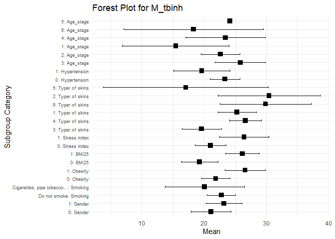

## Tạo bảng và Forest plot với biến Kv100_tbinh

| Subgroup_Category | Subgroup | n_Kv100_tbinh | Mean | CI_lower | CI_upper | P_Value |
| --- | --- | --- | --- | --- | --- | --- |
| Gender | 0 | 31 | 24.73460 | 19.591821 | 29.87737 | 0.0530761 |
| Gender | 1 | 44 | 18.63459 | 15.658456 | 21.61073 | 0.0530761 |
| Smoking | Do not smoke | 62 | 22.66100 | 19.472903 | 25.84909 | 0.0170149 |
| Smoking | Cigarettes, pipe tobacco… | 13 | 13.97790 | 11.108420 | 16.84737 | 0.0170149 |
| Obesity | 0 | 68 | 21.60154 | 18.605552 | 24.59753 | 0.4072802 |
| Obesity | 1 | 7 | 16.82711 | 10.450190 | 23.20402 | 0.4072802 |
| BMI25 | 0 | 42 | 24.02030 | 20.214603 | 27.82600 | 0.0085090 |
| BMI25 | 1 | 33 | 17.51036 | 13.648248 | 21.37247 | 0.0085090 |
| Stress index | 0 | 57 | 21.09870 | 17.912910 | 24.28450 | 0.8865572 |
| Stress index | 1 | 18 | 21.33713 | 15.162719 | 27.51154 | 0.8865572 |
| Typer of skins | 3 | 40 | 21.12525 | 16.982064 | 25.26844 | NA |
| Typer of skins | 4 | 11 | 20.61966 | 15.388200 | 25.85112 | NA |
| Typer of skins | 1 | 10 | 22.17056 | 12.588574 | 31.75254 | NA |
| Typer of skins | 6 | 4 | 14.05000 | 3.008453 | 25.09155 | NA |
| Typer of skins | 2 | 4 | 13.21000 | 3.587960 | 22.83204 | NA |
| Typer of skins | 5 | 6 | 30.68708 | 18.623599 | 42.75057 | NA |
| Hypertension | 0 | 54 | 22.71865 | 19.280025 | 26.15728 | 0.0631009 |
| Hypertension | 1 | 21 | 17.13749 | 12.805118 | 21.46986 | 0.0631009 |
| Age_stage | 3 | 13 | 15.25758 | 11.054682 | 19.46047 | NA |
| Age_stage | 2 | 36 | 23.93681 | 19.852199 | 28.02141 | NA |
| Age_stage | 1 | 7 | 27.28643 | 15.066358 | 39.50650 | NA |
| Age_stage | 4 | 12 | 12.07231 | 9.328772 | 14.81584 | NA |
| Age_stage | 6 | 6 | 28.58972 | 10.771627 | 46.40782 | NA |
| Age_stage | 5 | 1 | 19.21000 | NaN | NaN | NA |

Wilcox pairwise test cho các sub group có >2 level

```
## Group Gender does not have more than 2 unique levels. Skipping.
```

```
## Group Smoking does not have more than 2 unique levels. Skipping.
```

```
## Group Obesity does not have more than 2 unique levels. Skipping.
```

```
## Group BMI25 does not have more than 2 unique levels. Skipping.
```

```
## Group Stress index does not have more than 2 unique levels. Skipping.
```

```
## Group Hypertension does not have more than 2 unique levels. Skipping.
```

| Group | Group1 | Group2 | P_Value |
| --- | --- | --- | --- |
| Typer of skins | 3 | 4 | 0.7094372 |
| Typer of skins | 3 | 1 | 0.6758965 |
| Typer of skins | 3 | 6 | 0.3108780 |
| Typer of skins | 3 | 2 | 0.3108780 |
| Typer of skins | 3 | 5 | 0.0695713 |
| Typer of skins | 4 | 1 | 0.9176902 |
| Typer of skins | 4 | 6 | 0.1377289 |
| Typer of skins | 4 | 2 | 0.1040293 |
| Typer of skins | 4 | 5 | 0.0982547 |
| Typer of skins | 1 | 6 | 0.2397602 |
| Typer of skins | 1 | 2 | 0.3036963 |
| Typer of skins | 1 | 5 | 0.1805694 |
| Typer of skins | 6 | 2 | 0.8857143 |
| Typer of skins | 6 | 5 | 0.1142857 |
| Typer of skins | 2 | 5 | 0.0666667 |
| Age_stage | 3 | 2 | 0.0215123 |
| Age_stage | 3 | 1 | 0.0236068 |
| Age_stage | 3 | 4 | 0.2945372 |
| Age_stage | 3 | 6 | 0.1060740 |
| Age_stage | 3 | 5 | 0.7142857 |
| Age_stage | 2 | 1 | 0.4675625 |
| Age_stage | 2 | 4 | 0.0004619 |
| Age_stage | 2 | 6 | 0.6108976 |
| Age_stage | 2 | 5 | 0.8648649 |
| Age_stage | 1 | 4 | 0.0052393 |
| Age_stage | 1 | 6 | 0.9452214 |
| Age_stage | 1 | 5 | 0.5000000 |
| Age_stage | 4 | 6 | 0.0244559 |
| Age_stage | 4 | 5 | 0.3076923 |
| Age_stage | 6 | 5 | 1.0000000 |

Forest plot

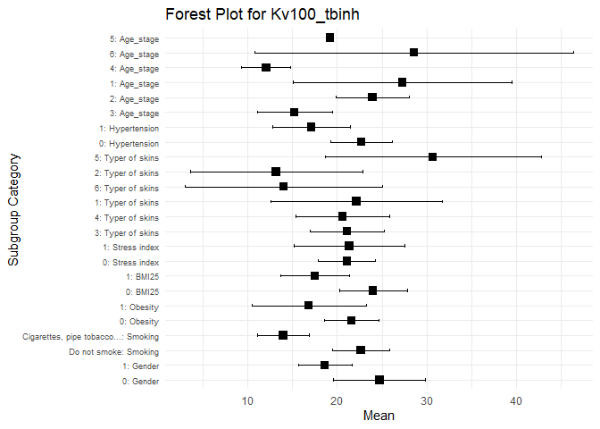

## Tạo bảng và Forest plot với biến δ_tbinh

| Subgroup_Category | Subgroup | n_δ_tbinh | Mean | CI_lower | CI_upper | P_Value |
| --- | --- | --- | --- | --- | --- | --- |
| Gender | 0 | 31 | 4.153401 | 3.4818036 | 4.824998 | 0.3011195 |
| Gender | 1 | 44 | 3.702398 | 3.1648978 | 4.239898 | 0.3011195 |
| Smoking | Do not smoke | 62 | 4.166082 | 3.7205771 | 4.611587 | 0.0047983 |
| Smoking | Cigarettes, pipe tobacco… | 13 | 2.566449 | 1.7218259 | 3.411071 | 0.0047983 |
| Obesity | 0 | 68 | 3.871607 | 3.4257188 | 4.317494 | 0.7088764 |
| Obesity | 1 | 7 | 4.055952 | 2.7982282 | 5.313676 | 0.7088764 |
| BMI25 | 0 | 42 | 3.925627 | 3.3028994 | 4.548355 | 0.8610502 |
| BMI25 | 1 | 33 | 3.841957 | 3.2997921 | 4.384122 | 0.8610502 |
| Stress index | 0 | 57 | 3.628956 | 3.1619289 | 4.095983 | 0.0158285 |
| Stress index | 1 | 18 | 4.711690 | 3.8662116 | 5.557168 | 0.0158285 |
| Typer of skins | 3 | 40 | 3.212929 | 2.7428353 | 3.683023 | NA |
| Typer of skins | 4 | 11 | 4.979886 | 3.8737574 | 6.086015 | NA |
| Typer of skins | 1 | 10 | 4.846250 | 3.7329454 | 5.959555 | NA |
| Typer of skins | 6 | 4 | 4.173750 | 0.4489826 | 7.898517 | NA |
| Typer of skins | 2 | 4 | 4.392500 | 1.9246288 | 6.860371 | NA |
| Typer of skins | 5 | 6 | 4.272917 | 1.3387716 | 7.207062 | NA |
| Hypertension | 0 | 54 | 4.352841 | 3.8710016 | 4.834681 | 0.0001557 |
| Hypertension | 1 | 21 | 2.695595 | 2.1200229 | 3.271167 | 0.0001557 |
| Age_stage | 3 | 13 | 3.559231 | 2.8083326 | 4.310129 | NA |
| Age_stage | 2 | 36 | 4.424294 | 3.8146686 | 5.033919 | NA |
| Age_stage | 1 | 7 | 3.373929 | 1.7262750 | 5.021582 | NA |
| Age_stage | 4 | 12 | 2.715319 | 1.7247761 | 3.705863 | NA |
| Age_stage | 6 | 6 | 4.250000 | 1.6980608 | 6.801939 | NA |
| Age_stage | 5 | 1 | 4.415000 | NaN | NaN | NA |

Wilcox pairwise test cho các sub group có >2 level

```
## Group Gender does not have more than 2 unique levels. Skipping.
```

```
## Group Smoking does not have more than 2 unique levels. Skipping.
```

```
## Group Obesity does not have more than 2 unique levels. Skipping.
```

```
## Group BMI25 does not have more than 2 unique levels. Skipping.
```

```
## Group Stress index does not have more than 2 unique levels. Skipping.
```

```
## Group Hypertension does not have more than 2 unique levels. Skipping.
```

| Group | Group1 | Group2 | P_Value |
| --- | --- | --- | --- |
| Typer of skins | 3 | 4 | 0.0036236 |
| Typer of skins | 3 | 1 | 0.0042442 |
| Typer of skins | 3 | 6 | 0.5410936 |
| Typer of skins | 3 | 2 | 0.1292808 |
| Typer of skins | 3 | 5 | 0.5342012 |
| Typer of skins | 4 | 1 | 0.8632668 |
| Typer of skins | 4 | 6 | 0.4893773 |
| Typer of skins | 4 | 2 | 0.6608059 |
| Typer of skins | 4 | 5 | 0.3501939 |
| Typer of skins | 1 | 6 | 0.5394605 |
| Typer of skins | 1 | 2 | 0.6353646 |
| Typer of skins | 1 | 5 | 0.3131868 |
| Typer of skins | 6 | 2 | 0.8857143 |
| Typer of skins | 6 | 5 | 0.9142857 |
| Typer of skins | 2 | 5 | 0.4761905 |
| Age_stage | 3 | 2 | 0.1656826 |
| Age_stage | 3 | 1 | 0.4854231 |
| Age_stage | 3 | 4 | 0.1095483 |
| Age_stage | 3 | 6 | 0.7012384 |
| Age_stage | 3 | 5 | 0.4285714 |
| Age_stage | 2 | 1 | 0.1555516 |
| Age_stage | 2 | 4 | 0.0048640 |
| Age_stage | 2 | 6 | 0.9302335 |
| Age_stage | 2 | 5 | 0.9729730 |
| Age_stage | 1 | 4 | 0.3844566 |
| Age_stage | 1 | 6 | 0.6282051 |
| Age_stage | 1 | 5 | 0.7500000 |
| Age_stage | 4 | 6 | 0.1505064 |
| Age_stage | 4 | 5 | 0.6153846 |
| Age_stage | 6 | 5 | 1.0000000 |

Forest plot

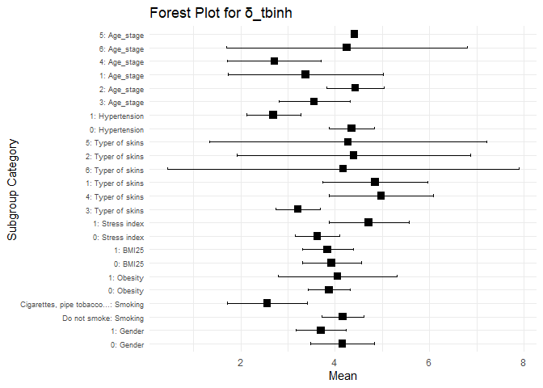

## Tạo bảng và Forest plot với biến T_tbinh

| Subgroup_Category | Subgroup | n_T_tbinh | Mean | CI_lower | CI_upper | P_Value |
| --- | --- | --- | --- | --- | --- | --- |
| Gender | 0 | 31 | 31.56098 | 30.41269 | 32.70927 | 0.9360886 |
| Gender | 1 | 44 | 30.98459 | 29.73156 | 32.23762 | 0.9360886 |
| Smoking | Do not smoke | 62 | 31.56217 | 30.72607 | 32.39826 | 0.3237671 |
| Smoking | Cigarettes, pipe tobacco… | 13 | 29.60447 | 26.44484 | 32.76411 | 0.3237671 |
| Obesity | 0 | 68 | 30.95489 | 30.03880 | 31.87097 | 0.0387181 |
| Obesity | 1 | 7 | 33.82573 | 32.20344 | 35.44801 | 0.0387181 |
| BMI25 | 0 | 42 | 30.18265 | 28.95837 | 31.40694 | 0.0024193 |
| BMI25 | 1 | 33 | 32.54669 | 31.47129 | 33.62210 | 0.0024193 |
| Stress index | 0 | 57 | 30.63827 | 29.57898 | 31.69755 | 0.0438131 |
| Stress index | 1 | 18 | 33.07396 | 32.16519 | 33.98273 | 0.0438131 |
| Typer of skins | 3 | 40 | 30.20477 | 28.91238 | 31.49716 | NA |
| Typer of skins | 4 | 11 | 33.21712 | 32.30750 | 34.12674 | NA |
| Typer of skins | 1 | 10 | 32.73534 | 31.08471 | 34.38598 | NA |
| Typer of skins | 6 | 4 | 34.73000 | 32.87327 | 36.58673 | NA |
| Typer of skins | 2 | 4 | 33.23875 | 28.49814 | 37.97936 | NA |
| Typer of skins | 5 | 6 | 28.15083 | 24.32469 | 31.97698 | NA |
| Hypertension | 0 | 54 | 31.64122 | 30.75757 | 32.52486 | 0.4395865 |
| Hypertension | 1 | 21 | 30.14699 | 28.00898 | 32.28499 | 0.4395865 |
| Age_stage | 3 | 13 | 32.34465 | 30.69692 | 33.99239 | NA |
| Age_stage | 2 | 36 | 31.56929 | 30.50723 | 32.63136 | NA |
| Age_stage | 1 | 7 | 28.53821 | 24.78248 | 32.29395 | NA |
| Age_stage | 4 | 12 | 31.14401 | 27.98124 | 34.30679 | NA |
| Age_stage | 6 | 6 | 29.58194 | 24.20772 | 34.95617 | NA |
| Age_stage | 5 | 1 | 33.75000 | NaN | NaN | NA |

Wilcox pairwise test cho các sub group có >2 level

```
## Group Gender does not have more than 2 unique levels. Skipping.
```

```
## Group Smoking does not have more than 2 unique levels. Skipping.
```

```
## Group Obesity does not have more than 2 unique levels. Skipping.
```

```
## Group BMI25 does not have more than 2 unique levels. Skipping.
```

```
## Group Stress index does not have more than 2 unique levels. Skipping.
```

```
## Group Hypertension does not have more than 2 unique levels. Skipping.
```

| Group | Group1 | Group2 | P_Value |
| --- | --- | --- | --- |
| Typer of skins | 3 | 4 | 0.0327598 |
| Typer of skins | 3 | 1 | 0.0628839 |
| Typer of skins | 3 | 6 | 0.0052891 |
| Typer of skins | 3 | 2 | 0.1404778 |
| Typer of skins | 3 | 5 | 0.2031633 |
| Typer of skins | 4 | 1 | 0.8632668 |
| Typer of skins | 4 | 6 | 0.1377289 |
| Typer of skins | 4 | 2 | 0.8512821 |
| Typer of skins | 4 | 5 | 0.0030705 |
| Typer of skins | 1 | 6 | 0.1058941 |
| Typer of skins | 1 | 2 | 0.7332667 |
| Typer of skins | 1 | 5 | 0.0109890 |
| Typer of skins | 6 | 2 | 0.6857143 |
| Typer of skins | 6 | 5 | 0.0095238 |
| Typer of skins | 2 | 5 | 0.0666667 |
| Age_stage | 3 | 2 | 0.5988941 |
| Age_stage | 3 | 1 | 0.0236068 |
| Age_stage | 3 | 4 | 1.0000000 |
| Age_stage | 3 | 6 | 0.3228660 |
| Age_stage | 3 | 5 | 0.7142857 |
| Age_stage | 2 | 1 | 0.0448398 |
| Age_stage | 2 | 4 | 0.4727990 |
| Age_stage | 2 | 6 | 0.4494083 |
| Age_stage | 2 | 5 | 0.4324324 |
| Age_stage | 1 | 4 | 0.2991188 |
| Age_stage | 1 | 6 | 0.8356643 |
| Age_stage | 1 | 5 | 0.5000000 |
| Age_stage | 4 | 6 | 0.8200819 |
| Age_stage | 4 | 5 | 1.0000000 |
| Age_stage | 6 | 5 | 0.8571429 |

Forest plot

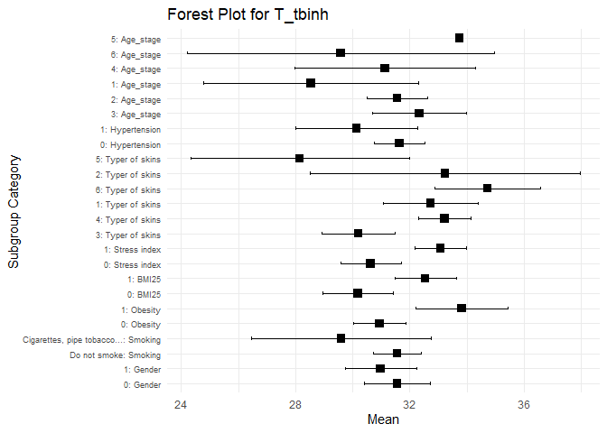

## Tạo bảng và Forest plot với biến A365_tbinh

| Subgroup_Category | Subgroup | n_A365_tbinh | Mean | CI_lower | CI_upper | P_Value |
| --- | --- | --- | --- | --- | --- | --- |
| Gender | 0 | 31 | 87.05108 | 72.4408672 | 101.66128 | 0.7550195 |
| Gender | 1 | 44 | 85.25644 | 74.1461593 | 96.36672 | 0.7550195 |
| Smoking | Do not smoke | 62 | 87.19946 | 77.8778461 | 96.52108 | 0.8391691 |
| Smoking | Cigarettes, pipe tobacco… | 13 | 80.26923 | 54.1757982 | 106.36266 | 0.8391691 |
| Obesity | 0 | 68 | 84.53309 | 75.1073373 | 93.95884 | 0.4228977 |
| Obesity | 1 | 7 | 100.23095 | 83.7090898 | 116.75281 | 0.4228977 |
| BMI25 | 0 | 42 | 85.08730 | 71.6948859 | 98.47972 | 0.7691166 |
| BMI25 | 1 | 33 | 87.15758 | 76.4330720 | 97.88208 | 0.7691166 |
| Stress index | 0 | 57 | 85.39094 | 75.6039595 | 95.17791 | 0.8184730 |
| Stress index | 1 | 18 | 87.92130 | 67.4526124 | 108.38998 | 0.8184730 |
| Typer of skins | 3 | 40 | 94.44375 | 84.8793268 | 104.00817 | NA |
| Typer of skins | 4 | 11 | 95.14394 | 72.4079018 | 117.87998 | NA |
| Typer of skins | 1 | 10 | 107.00333 | 94.4911286 | 119.51554 | NA |
| Typer of skins | 6 | 4 | 14.62500 | -9.0959249 | 38.34592 | NA |
| Typer of skins | 2 | 4 | 73.75000 | 0.8121885 | 146.68781 | NA |
| Typer of skins | 5 | 6 | 33.66667 | 6.1909532 | 61.14238 | NA |
| Hypertension | 0 | 54 | 84.05864 | 73.4131523 | 94.70413 | 0.4155155 |
| Hypertension | 1 | 21 | 90.98571 | 75.3057783 | 106.66565 | 0.4155155 |
| Age_stage | 3 | 13 | 88.40000 | 70.5934317 | 106.20657 | NA |
| Age_stage | 2 | 36 | 86.89120 | 74.0442601 | 99.73815 | NA |
| Age_stage | 1 | 7 | 89.96429 | 41.7201797 | 138.20839 | NA |
| Age_stage | 4 | 12 | 84.45833 | 58.7534340 | 110.16323 | NA |
| Age_stage | 6 | 6 | 84.80556 | 50.5458764 | 119.06523 | NA |
| Age_stage | 5 | 1 | 20.50000 | NaN | NaN | NA |

Wilcox pairwise test cho các sub group có >2 level

```
## Group Gender does not have more than 2 unique levels. Skipping.
```

```
## Group Smoking does not have more than 2 unique levels. Skipping.
```

```
## Group Obesity does not have more than 2 unique levels. Skipping.
```

```
## Group BMI25 does not have more than 2 unique levels. Skipping.
```

```
## Group Stress index does not have more than 2 unique levels. Skipping.
```

```
## Group Hypertension does not have more than 2 unique levels. Skipping.
```

| Group | Group1 | Group2 | P_Value |
| --- | --- | --- | --- |
| Typer of skins | 3 | 4 | 0.7398131 |
| Typer of skins | 3 | 1 | 0.2160683 |
| Typer of skins | 3 | 6 | 0.0020520 |
| Typer of skins | 3 | 2 | 0.4500455 |
| Typer of skins | 3 | 5 | 0.0009301 |
| Typer of skins | 4 | 1 | 0.1389435 |
| Typer of skins | 4 | 6 | 0.0049617 |
| Typer of skins | 4 | 2 | 0.3270554 |
| Typer of skins | 4 | 5 | 0.0056827 |
| Typer of skins | 1 | 6 | 0.0019980 |
| Typer of skins | 1 | 2 | 0.1418581 |
| Typer of skins | 1 | 5 | 0.0009990 |
| Typer of skins | 6 | 2 | 0.1142857 |
| Typer of skins | 6 | 5 | 0.2571429 |
| Typer of skins | 2 | 5 | 0.2571429 |
| Age_stage | 3 | 2 | 0.9368231 |
| Age_stage | 3 | 1 | 0.8429029 |
| Age_stage | 3 | 4 | 0.9566139 |
| Age_stage | 3 | 6 | 0.9660917 |
| Age_stage | 3 | 5 | 0.2857143 |
| Age_stage | 2 | 1 | 0.8564065 |
| Age_stage | 2 | 4 | 0.9525298 |
| Age_stage | 2 | 6 | 1.0000000 |
| Age_stage | 2 | 5 | 0.1743969 |
| Age_stage | 1 | 4 | 0.7108439 |
| Age_stage | 1 | 6 | 0.7307692 |
| Age_stage | 1 | 5 | 0.5000000 |
| Age_stage | 4 | 6 | 0.8916182 |
| Age_stage | 4 | 5 | 0.4615385 |
| Age_stage | 6 | 5 | 0.2857143 |

Forest plot

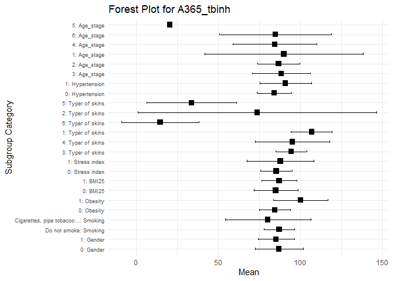

## Tạo bảng và Forest plot với biến A460_tbinh

| Subgroup_Category | Subgroup | n_A460_tbinh | Mean | CI_lower | CI_upper | P_Value |
| --- | --- | --- | --- | --- | --- | --- |
| Gender | 0 | 31 | 58.46640 | 50.72173 | 66.21107 | 0.8464227 |
| Gender | 1 | 44 | 60.14242 | 52.23436 | 68.05049 | 0.8464227 |
| Smoking | Do not smoke | 62 | 57.94126 | 52.76723 | 63.11530 | 0.3411697 |
| Smoking | Cigarettes, pipe tobacco… | 13 | 66.64359 | 44.31555 | 88.97163 | 0.3411697 |
| Obesity | 0 | 68 | 58.61385 | 52.63851 | 64.58919 | 0.2784596 |
| Obesity | 1 | 7 | 67.56905 | 54.60883 | 80.52927 | 0.2784596 |
| BMI25 | 0 | 42 | 58.84206 | 50.12882 | 67.55531 | 0.7206452 |
| BMI25 | 1 | 33 | 60.22298 | 53.82200 | 66.62396 | 0.7206452 |
| Stress index | 0 | 57 | 60.73275 | 54.34136 | 67.12414 | 0.5681973 |
| Stress index | 1 | 18 | 55.38657 | 43.54841 | 67.22474 | 0.5681973 |
| Typer of skins | 3 | 40 | 69.09875 | 62.52101 | 75.67649 | NA |
| Typer of skins | 4 | 11 | 59.94318 | 45.16838 | 74.71798 | NA |
| Typer of skins | 1 | 10 | 60.51500 | 54.10929 | 66.92071 | NA |
| Typer of skins | 6 | 4 | 13.75000 | 10.22169 | 17.27831 | NA |
| Typer of skins | 2 | 4 | 52.12500 | 20.96129 | 83.28871 | NA |
| Typer of skins | 5 | 6 | 27.79167 | 13.12731 | 42.45602 | NA |
| Hypertension | 0 | 54 | 54.06620 | 48.33938 | 59.79303 | 0.0015951 |
| Hypertension | 1 | 21 | 73.29286 | 61.42427 | 85.16145 | 0.0015951 |
| Age_stage | 3 | 13 | 63.31923 | 50.87857 | 75.75990 | NA |
| Age_stage | 2 | 36 | 55.39468 | 47.91375 | 62.87560 | NA |
| Age_stage | 1 | 7 | 62.42857 | 42.76666 | 82.09048 | NA |
| Age_stage | 4 | 12 | 70.11389 | 51.78901 | 88.43877 | NA |
| Age_stage | 6 | 6 | 57.83333 | 26.90355 | 88.76311 | NA |
| Age_stage | 5 | 1 | 16.00000 | NaN | NaN | NA |

Wilcox pairwise test cho các sub group có >2 level

```
## Group Gender does not have more than 2 unique levels. Skipping.
```

```
## Group Smoking does not have more than 2 unique levels. Skipping.
```

```
## Group Obesity does not have more than 2 unique levels. Skipping.
```

```
## Group BMI25 does not have more than 2 unique levels. Skipping.
```

```
## Group Stress index does not have more than 2 unique levels. Skipping.
```

```
## Group Hypertension does not have more than 2 unique levels. Skipping.
```

| Group | Group1 | Group2 | P_Value |
| --- | --- | --- | --- |
| Typer of skins | 3 | 4 | 0.1657543 |
| Typer of skins | 3 | 1 | 0.1263822 |
| Typer of skins | 3 | 6 | 0.0011656 |
| Typer of skins | 3 | 2 | 0.1843559 |
| Typer of skins | 3 | 5 | 0.0002417 |
| Typer of skins | 4 | 1 | 0.6539029 |
| Typer of skins | 4 | 6 | 0.0014652 |
| Typer of skins | 4 | 2 | 0.6608059 |
| Typer of skins | 4 | 5 | 0.0071105 |
| Typer of skins | 1 | 6 | 0.0019980 |
| Typer of skins | 1 | 2 | 0.5394605 |
| Typer of skins | 1 | 5 | 0.0009990 |
| Typer of skins | 6 | 2 | 0.0285714 |
| Typer of skins | 6 | 5 | 0.0666667 |
| Typer of skins | 2 | 5 | 0.1142857 |
| Age_stage | 3 | 2 | 0.4213977 |
| Age_stage | 3 | 1 | 1.0000000 |
| Age_stage | 3 | 4 | 0.4626779 |
| Age_stage | 3 | 6 | 0.7923711 |
| Age_stage | 3 | 5 | 0.1428571 |
| Age_stage | 2 | 1 | 0.4896111 |
| Age_stage | 2 | 4 | 0.0800282 |
| Age_stage | 2 | 6 | 0.8998783 |
| Age_stage | 2 | 5 | 0.1743969 |
| Age_stage | 1 | 4 | 0.5259869 |
| Age_stage | 1 | 6 | 0.7307692 |
| Age_stage | 1 | 5 | 0.2500000 |
| Age_stage | 4 | 6 | 0.1463744 |
| Age_stage | 4 | 5 | 0.1410316 |
| Age_stage | 6 | 5 | 0.5714286 |

Forest plot

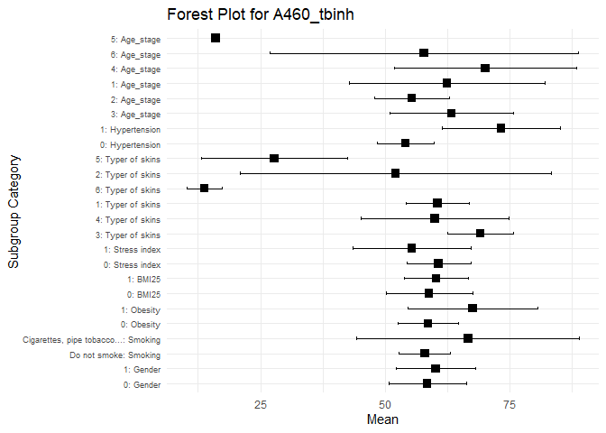

## Tạo bảng và Forest plot với biến Anadn_tbinh

| Subgroup_Category | Subgroup | n_Anadn_tbinh | Mean | CI_lower | CI_upper | P_Value |
| --- | --- | --- | --- | --- | --- | --- |
| Gender | 0 | 31 | 1.0937231 | 0.6485180 | 1.5389282 | 0.1508905 |
| Gender | 1 | 44 | 0.9720871 | 0.6892931 | 1.2548811 | 0.1508905 |
| Smoking | Do not smoke | 62 | 0.9212567 | 0.6973887 | 1.1451247 | 0.0209165 |
| Smoking | Cigarettes, pipe tobacco… | 13 | 1.5045641 | 0.5394606 | 2.4696676 | 0.0209165 |
| Obesity | 0 | 68 | 1.0528395 | 0.7869535 | 1.3187254 | 0.7846964 |
| Obesity | 1 | 7 | 0.7263095 | 0.5817304 | 0.8708887 | 0.7846964 |
| BMI25 | 0 | 42 | 1.1083175 | 0.7487027 | 1.4679323 | 0.9192323 |
| BMI25 | 1 | 33 | 0.9129672 | 0.5911365 | 1.2347978 | 0.9192323 |
| Stress index | 0 | 57 | 1.0102076 | 0.7373758 | 1.2830394 | 0.4454884 |
| Stress index | 1 | 18 | 1.0608565 | 0.4897221 | 1.6319908 | 0.4454884 |
| Typer of skins | 3 | 40 | 0.9509000 | 0.6525815 | 1.2492185 | NA |
| Typer of skins | 4 | 11 | 0.6610227 | 0.5396172 | 0.7824283 | NA |
| Typer of skins | 1 | 10 | 0.5950000 | 0.5076194 | 0.6823806 | NA |
| Typer of skins | 6 | 4 | 2.5737500 | -0.3925575 | 5.5400575 | NA |
| Typer of skins | 2 | 4 | 1.3400000 | -0.0735341 | 2.7535341 | NA |
| Typer of skins | 5 | 6 | 1.6275000 | -0.4066713 | 3.6616713 | NA |
| Hypertension | 0 | 54 | 0.9382824 | 0.6873593 | 1.1892056 | 0.0682814 |
| Hypertension | 1 | 21 | 1.2385714 | 0.6320136 | 1.8451292 | 0.0682814 |
| Age_stage | 3 | 13 | 0.9359615 | 0.6101144 | 1.2618087 | NA |
| Age_stage | 2 | 36 | 0.8847338 | 0.5969270 | 1.1725406 | NA |
| Age_stage | 1 | 7 | 1.1203571 | 0.1101930 | 2.1305213 | NA |
| Age_stage | 4 | 12 | 1.6074444 | 0.3928301 | 2.8220588 | NA |
| Age_stage | 6 | 6 | 0.7679167 | 0.5896037 | 0.9462296 | NA |
| Age_stage | 5 | 1 | 0.9200000 | NaN | NaN | NA |

Wilcox pairwise test cho các sub group có >2 level

```
## Group Gender does not have more than 2 unique levels. Skipping.
```

```
## Group Smoking does not have more than 2 unique levels. Skipping.
```

```
## Group Obesity does not have more than 2 unique levels. Skipping.
```

```
## Group BMI25 does not have more than 2 unique levels. Skipping.
```

```
## Group Stress index does not have more than 2 unique levels. Skipping.
```

```
## Group Hypertension does not have more than 2 unique levels. Skipping.
```

| Group | Group1 | Group2 | P_Value |
| --- | --- | --- | --- |
| Typer of skins | 3 | 4 | 0.1802925 |
| Typer of skins | 3 | 1 | 0.0318297 |
| Typer of skins | 3 | 6 | 0.0095265 |
| Typer of skins | 3 | 2 | 0.2445904 |
| Typer of skins | 3 | 5 | 0.1559279 |
| Typer of skins | 4 | 1 | 0.5261025 |
| Typer of skins | 4 | 6 | 0.0029304 |
| Typer of skins | 4 | 2 | 0.1377289 |
| Typer of skins | 4 | 5 | 0.0365223 |
| Typer of skins | 1 | 6 | 0.0019980 |
| Typer of skins | 1 | 2 | 0.0359640 |
| Typer of skins | 1 | 5 | 0.0029970 |
| Typer of skins | 6 | 2 | 0.3428571 |
| Typer of skins | 6 | 5 | 0.1714286 |
| Typer of skins | 2 | 5 | 1.0000000 |
| Age_stage | 3 | 2 | 0.1320658 |
| Age_stage | 3 | 1 | 0.6991744 |
| Age_stage | 3 | 4 | 0.6243960 |
| Age_stage | 3 | 6 | 0.6388029 |
| Age_stage | 3 | 5 | 0.7142857 |
| Age_stage | 2 | 1 | 0.3923109 |
| Age_stage | 2 | 4 | 0.0330835 |
| Age_stage | 2 | 6 | 0.3407928 |
| Age_stage | 2 | 5 | 0.2416506 |
| Age_stage | 1 | 4 | 0.5358419 |
| Age_stage | 1 | 6 | 1.0000000 |
| Age_stage | 1 | 5 | 0.7500000 |
| Age_stage | 4 | 6 | 0.4534622 |
| Age_stage | 4 | 5 | 0.7692308 |
| Age_stage | 6 | 5 | 0.5714286 |

Forest plot

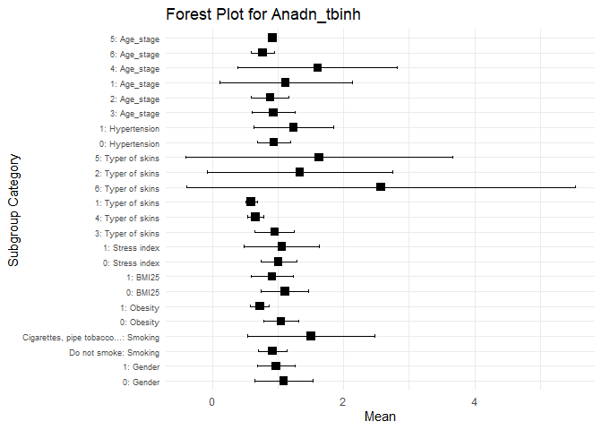

## Tạo bảng và Forest plot với biến POM_tbinh

| Subgroup_Category | Subgroup | n_POM_tbinh | Mean | CI_lower | CI_upper | P_Value |
| --- | --- | --- | --- | --- | --- | --- |
| Gender | 0 | 31 | 8.160255 | 6.0416227 | 10.278888 | 0.5454925 |
| Gender | 1 | 44 | 8.535189 | 7.0556788 | 10.014700 | 0.5454925 |
| Smoking | Do not smoke | 62 | 8.840071 | 7.5369872 | 10.143155 | 0.0636644 |
| Smoking | Cigarettes, pipe tobacco… | 13 | 6.187064 | 2.9705711 | 9.403557 | 0.0636644 |
| Obesity | 0 | 68 | 8.270995 | 6.9496047 | 9.592386 | 0.2626726 |
| Obesity | 1 | 7 | 9.441226 | 7.9179523 | 10.964500 | 0.2626726 |
| BMI25 | 0 | 42 | 7.393754 | 5.6930463 | 9.094462 | 0.0276765 |
| BMI25 | 1 | 33 | 9.635715 | 7.9682968 | 11.303133 | 0.0276765 |
| Stress index | 0 | 57 | 7.667997 | 6.3465341 | 8.989460 | 0.0243490 |
| Stress index | 1 | 18 | 10.635579 | 7.9058975 | 13.365260 | 0.0243490 |
| Typer of skins | 3 | 40 | 6.905462 | 5.4848898 | 8.326035 | NA |
| Typer of skins | 4 | 11 | 12.312500 | 8.9465217 | 15.678478 | NA |
| Typer of skins | 1 | 10 | 11.521775 | 8.5320916 | 14.511458 | NA |
| Typer of skins | 6 | 4 | 6.775000 | -3.8197345 | 17.369734 | NA |
| Typer of skins | 2 | 4 | 11.825000 | 0.5152105 | 23.134790 | NA |
| Typer of skins | 5 | 6 | 4.540417 | 0.9836002 | 8.097233 | NA |
| Hypertension | 0 | 54 | 9.456593 | 7.9817510 | 10.931434 | 0.0048888 |
| Hypertension | 1 | 21 | 5.612393 | 4.0003209 | 7.224465 | 0.0048888 |
| Age_stage | 3 | 13 | 8.474731 | 6.0041592 | 10.945302 | NA |
| Age_stage | 2 | 36 | 9.355081 | 7.4435184 | 11.266644 | NA |
| Age_stage | 1 | 7 | 7.366429 | 1.3631938 | 13.369663 | NA |
| Age_stage | 4 | 12 | 6.350569 | 3.4885632 | 9.212576 | NA |
| Age_stage | 6 | 6 | 7.775833 | 2.3574457 | 13.194221 | NA |
| Age_stage | 5 | 1 | 7.135000 | NaN | NaN | NA |

Wilcox pairwise test cho các sub group có >2 level

```
## Group Gender does not have more than 2 unique levels. Skipping.
```

```
## Group Smoking does not have more than 2 unique levels. Skipping.
```

```
## Group Obesity does not have more than 2 unique levels. Skipping.
```

```
## Group BMI25 does not have more than 2 unique levels. Skipping.
```

```
## Group Stress index does not have more than 2 unique levels. Skipping.
```

```
## Group Hypertension does not have more than 2 unique levels. Skipping.
```

| Group | Group1 | Group2 | P_Value |
| --- | --- | --- | --- |
| Typer of skins | 3 | 4 | 0.0019856 |
| Typer of skins | 3 | 1 | 0.0032536 |
| Typer of skins | 3 | 6 | 0.5947949 |
| Typer of skins | 3 | 2 | 0.1187026 |
| Typer of skins | 3 | 5 | 0.2276480 |
| Typer of skins | 4 | 1 | 0.8632668 |
| Typer of skins | 4 | 6 | 0.1377289 |
| Typer of skins | 4 | 2 | 0.8512821 |
| Typer of skins | 4 | 5 | 0.0030705 |
| Typer of skins | 1 | 6 | 0.1418581 |
| Typer of skins | 1 | 2 | 0.9450549 |
| Typer of skins | 1 | 5 | 0.0029970 |
| Typer of skins | 6 | 2 | 0.2000000 |
| Typer of skins | 6 | 5 | 1.0000000 |
| Typer of skins | 2 | 5 | 0.1142857 |
| Age_stage | 3 | 2 | 0.8492626 |
| Age_stage | 3 | 1 | 0.7573013 |
| Age_stage | 3 | 4 | 0.1860700 |
| Age_stage | 3 | 6 | 0.5788737 |
| Age_stage | 3 | 5 | 0.8571429 |
| Age_stage | 2 | 1 | 0.3394958 |
| Age_stage | 2 | 4 | 0.0983976 |
| Age_stage | 2 | 6 | 0.5387791 |
| Age_stage | 2 | 5 | 0.6486486 |
| Age_stage | 1 | 4 | 0.8369453 |
| Age_stage | 1 | 6 | 0.8356643 |
| Age_stage | 1 | 5 | 1.0000000 |
| Age_stage | 4 | 6 | 0.4936436 |
| Age_stage | 4 | 5 | 0.9230769 |
| Age_stage | 6 | 5 | 0.8571429 |

Forest plot

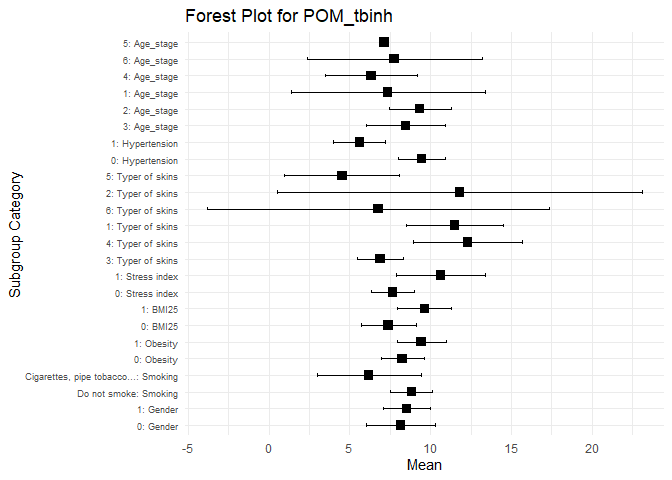

## Tạo bảng và Forest plot với biến Ae_tbinh

| Subgroup_Category | Subgroup | n_Ae_tbinh | Mean | CI_lower | CI_upper | P_Value |
| --- | --- | --- | --- | --- | --- | --- |
| Gender | 0 | 31 | 1.4660753 | 1.2682789 | 1.663872 | 0.4776379 |
| Gender | 1 | 44 | 1.4789129 | 1.1904953 | 1.767330 | 0.4776379 |
| Smoking | Do not smoke | 62 | 1.5980618 | 1.4004434 | 1.795680 | 0.0013172 |
| Smoking | Cigarettes, pipe tobacco… | 13 | 0.8800513 | 0.4921186 | 1.267984 | 0.0013172 |
| Obesity | 0 | 68 | 1.4293787 | 1.2389141 | 1.619843 | 0.1238030 |
| Obesity | 1 | 7 | 1.9032500 | 1.1010252 | 2.705475 | 0.1238030 |
| BMI25 | 0 | 42 | 1.4458095 | 1.1884594 | 1.703160 | 0.6616676 |
| BMI25 | 1 | 33 | 1.5089848 | 1.2329837 | 1.784986 | 0.6616676 |
| Stress index | 0 | 57 | 1.4426404 | 1.2175437 | 1.667737 | 0.2860303 |
| Stress index | 1 | 18 | 1.5716667 | 1.2549930 | 1.888340 | 0.2860303 |
| Typer of skins | 3 | 40 | 1.2086208 | 0.9987070 | 1.418535 | NA |
| Typer of skins | 4 | 11 | 1.8582955 | 1.4473440 | 2.269247 | NA |
| Typer of skins | 1 | 10 | 2.1116917 | 1.4877003 | 2.735683 | NA |
| Typer of skins | 6 | 4 | 1.2362500 | 0.1228793 | 2.349621 | NA |
| Typer of skins | 2 | 4 | 1.5937500 | 0.3620265 | 2.825474 | NA |
| Typer of skins | 5 | 6 | 1.5495833 | 0.2270473 | 2.872119 | NA |
| Hypertension | 0 | 54 | 1.6206991 | 1.4045658 | 1.836832 | 0.0075246 |
| Hypertension | 1 | 21 | 1.0953690 | 0.7731891 | 1.417549 | 0.0075246 |
| Age_stage | 3 | 13 | 1.4126154 | 1.0505562 | 1.774675 | NA |
| Age_stage | 2 | 36 | 1.6371991 | 1.3769027 | 1.897495 | NA |
| Age_stage | 1 | 7 | 1.1621429 | 0.6118347 | 1.712451 | NA |
| Age_stage | 4 | 12 | 1.0371389 | 0.5868378 | 1.487440 | NA |
| Age_stage | 6 | 6 | 1.8269444 | 0.3438377 | 3.310051 | NA |
| Age_stage | 5 | 1 | 1.6750000 | NaN | NaN | NA |

Wilcox pairwise test cho các sub group có >2 level

```
## Group Gender does not have more than 2 unique levels. Skipping.
```

```
## Group Smoking does not have more than 2 unique levels. Skipping.
```

```
## Group Obesity does not have more than 2 unique levels. Skipping.
```

```
## Group BMI25 does not have more than 2 unique levels. Skipping.
```

```
## Group Stress index does not have more than 2 unique levels. Skipping.
```

```
## Group Hypertension does not have more than 2 unique levels. Skipping.
```

| Group | Group1 | Group2 | P_Value |
| --- | --- | --- | --- |
| Typer of skins | 3 | 4 | 0.0023686 |
| Typer of skins | 3 | 1 | 0.0015287 |
| Typer of skins | 3 | 6 | 0.7980346 |
| Typer of skins | 3 | 2 | 0.2884705 |
| Typer of skins | 3 | 5 | 0.5992374 |
| Typer of skins | 4 | 1 | 0.5572642 |
| Typer of skins | 4 | 6 | 0.1772894 |
| Typer of skins | 4 | 2 | 0.6608059 |
| Typer of skins | 4 | 5 | 0.1489981 |
| Typer of skins | 1 | 6 | 0.1418581 |
| Typer of skins | 1 | 2 | 0.3736264 |
| Typer of skins | 1 | 5 | 0.1471029 |
| Typer of skins | 6 | 2 | 0.3428571 |
| Typer of skins | 6 | 5 | 0.7619048 |
| Typer of skins | 2 | 5 | 0.7619048 |
| Age_stage | 3 | 2 | 0.4897499 |
| Age_stage | 3 | 1 | 0.4279369 |
| Age_stage | 3 | 4 | 0.1210230 |
| Age_stage | 3 | 6 | 0.6929541 |
| Age_stage | 3 | 5 | 0.6194112 |
| Age_stage | 2 | 1 | 0.0842123 |
| Age_stage | 2 | 4 | 0.0201341 |
| Age_stage | 2 | 6 | 0.9860280 |
| Age_stage | 2 | 5 | 0.8108108 |
| Age_stage | 1 | 4 | 0.4824164 |
| Age_stage | 1 | 6 | 0.7307692 |
| Age_stage | 1 | 5 | 0.5000000 |
| Age_stage | 4 | 6 | 0.2496229 |
| Age_stage | 4 | 5 | 0.4615385 |
| Age_stage | 6 | 5 | 1.0000000 |

Forest plot

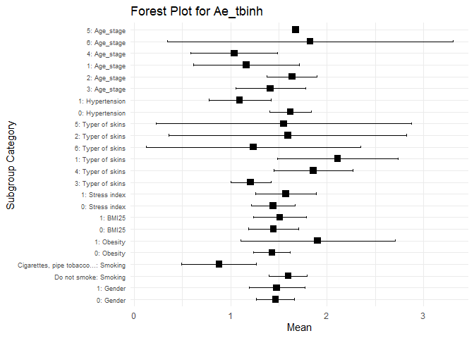

## Tạo bảng và Forest plot với biến An_tbinh

| Subgroup_Category | Subgroup | n_An_tbinh | Mean | CI_lower | CI_upper | P_Value |
| --- | --- | --- | --- | --- | --- | --- |
| Gender | 0 | 31 | 1.4210753 | 1.2001247 | 1.642026 | 0.6359246 |
| Gender | 1 | 44 | 1.4423636 | 1.1784347 | 1.706292 | 0.6359246 |
| Smoking | Do not smoke | 62 | 1.5291129 | 1.3426953 | 1.715531 | 0.0067624 |
| Smoking | Cigarettes, pipe tobacco… | 13 | 0.9778718 | 0.5109772 | 1.444766 | 0.0067624 |
| Obesity | 0 | 68 | 1.4006471 | 1.2167069 | 1.584587 | 0.2785074 |
| Obesity | 1 | 7 | 1.7533333 | 1.0155474 | 2.491119 | 0.2785074 |
| BMI25 | 0 | 42 | 1.3810278 | 1.1389835 | 1.623072 | 0.5862030 |
| BMI25 | 1 | 33 | 1.5004293 | 1.2322826 | 1.768576 | 0.5862030 |
| Stress index | 0 | 57 | 1.4030380 | 1.1977562 | 1.608320 | 0.4833598 |
| Stress index | 1 | 18 | 1.5302315 | 1.1573505 | 1.903112 | 0.4833598 |
| Typer of skins | 3 | 40 | 1.1676833 | 0.9671601 | 1.368207 | NA |
| Typer of skins | 4 | 11 | 1.6953788 | 1.2280429 | 2.162715 | NA |
| Typer of skins | 1 | 10 | 2.0475833 | 1.5677389 | 2.527428 | NA |
| Typer of skins | 6 | 4 | 1.5975000 | -0.2742175 | 3.469218 | NA |
| Typer of skins | 2 | 4 | 1.7187500 | 0.4618117 | 2.975688 | NA |
| Typer of skins | 5 | 6 | 1.4033333 | 0.3263973 | 2.480269 | NA |
| Hypertension | 0 | 54 | 1.5655525 | 1.3634495 | 1.767655 | 0.0075246 |
| Hypertension | 1 | 21 | 1.0941667 | 0.7584101 | 1.429923 | 0.0075246 |
| Age_stage | 3 | 13 | 1.3125000 | 0.9876147 | 1.637385 | NA |
| Age_stage | 2 | 36 | 1.5798380 | 1.3235015 | 1.836174 | NA |
| Age_stage | 1 | 7 | 1.0996429 | 0.6021487 | 1.597137 | NA |
| Age_stage | 4 | 12 | 1.1435278 | 0.6161617 | 1.670894 | NA |
| Age_stage | 6 | 6 | 1.6784722 | 0.4469334 | 2.910011 | NA |
| Age_stage | 5 | 1 | 2.0900000 | NaN | NaN | NA |

Wilcox pairwise test cho các sub group có >2 level

```
## Group Gender does not have more than 2 unique levels. Skipping.
```

```
## Group Smoking does not have more than 2 unique levels. Skipping.
```

```
## Group Obesity does not have more than 2 unique levels. Skipping.
```

```
## Group BMI25 does not have more than 2 unique levels. Skipping.
```

```
## Group Stress index does not have more than 2 unique levels. Skipping.
```

```
## Group Hypertension does not have more than 2 unique levels. Skipping.
```

| Group | Group1 | Group2 | P_Value |
| --- | --- | --- | --- |
| Typer of skins | 3 | 4 | 0.0185432 |
| Typer of skins | 3 | 1 | 0.0008264 |
| Typer of skins | 3 | 6 | 0.7084147 |
| Typer of skins | 3 | 2 | 0.1649638 |
| Typer of skins | 3 | 5 | 0.7869508 |
| Typer of skins | 4 | 1 | 0.1971161 |
| Typer of skins | 4 | 6 | 0.8512821 |
| Typer of skins | 4 | 2 | 1.0000000 |
| Typer of skins | 4 | 5 | 0.3010666 |
| Typer of skins | 1 | 6 | 0.6353646 |
| Typer of skins | 1 | 2 | 0.6710327 |
| Typer of skins | 1 | 5 | 0.1178821 |
| Typer of skins | 6 | 2 | 0.6857143 |
| Typer of skins | 6 | 5 | 1.0000000 |
| Typer of skins | 2 | 5 | 0.6095238 |
| Age_stage | 3 | 2 | 0.3028230 |
| Age_stage | 3 | 1 | 0.3832086 |
| Age_stage | 3 | 4 | 0.3410678 |
| Age_stage | 3 | 6 | 0.7587634 |
| Age_stage | 3 | 5 | 0.2143426 |
| Age_stage | 2 | 1 | 0.1459701 |
| Age_stage | 2 | 4 | 0.0610007 |
| Age_stage | 2 | 6 | 0.9860280 |
| Age_stage | 2 | 5 | 0.5405405 |
| Age_stage | 1 | 4 | 0.9671350 |
| Age_stage | 1 | 6 | 0.4452214 |
| Age_stage | 1 | 5 | 0.2500000 |
| Age_stage | 4 | 6 | 0.3354880 |
| Age_stage | 4 | 5 | 0.4615385 |
| Age_stage | 6 | 5 | 1.0000000 |

Forest plot

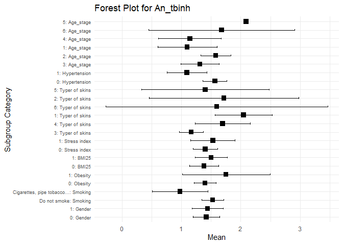

## Tạo bảng và Forest plot với biến Am_tbinh

| Subgroup_Category | Subgroup | n_Am_tbinh | Mean | CI_lower | CI_upper | P_Value |
| --- | --- | --- | --- | --- | --- | --- |
| Gender | 0 | 31 | 1.1518952 | 0.9568637 | 1.346927 | 0.8087154 |
| Gender | 1 | 44 | 1.1434848 | 0.9454501 | 1.341520 | 0.8087154 |
| Smoking | Do not smoke | 62 | 1.2235013 | 1.0769240 | 1.370079 | 0.0064822 |
| Smoking | Cigarettes, pipe tobacco… | 13 | 0.7819231 | 0.4197796 | 1.144067 | 0.0064822 |
| Obesity | 0 | 68 | 1.1440502 | 0.9943423 | 1.293758 | 0.7568465 |
| Obesity | 1 | 7 | 1.1752381 | 0.7809312 | 1.569545 | 0.7568465 |
| BMI25 | 0 | 42 | 1.1192460 | 0.9286871 | 1.309805 | 0.7047543 |
| BMI25 | 1 | 33 | 1.1822348 | 0.9713209 | 1.393149 | 0.7047543 |
| Stress index | 0 | 57 | 1.1068275 | 0.9470819 | 1.266573 | 0.2804613 |
| Stress index | 1 | 18 | 1.2740509 | 0.9774815 | 1.570620 | 0.2804613 |
| Typer of skins | 3 | 40 | 0.9471667 | 0.7720734 | 1.122260 | NA |
| Typer of skins | 4 | 11 | 1.4578409 | 1.0704160 | 1.845266 | NA |
| Typer of skins | 1 | 10 | 1.4709167 | 1.1330000 | 1.808833 | NA |
| Typer of skins | 6 | 4 | 1.1962500 | 0.0266672 | 2.365833 | NA |
| Typer of skins | 2 | 4 | 1.4212500 | 0.6044038 | 2.238096 | NA |
| Typer of skins | 5 | 6 | 1.1533333 | 0.3044416 | 2.002225 | NA |
| Hypertension | 0 | 54 | 1.2713812 | 1.1090521 | 1.433710 | 0.0034290 |
| Hypertension | 1 | 21 | 0.8270238 | 0.5995348 | 1.054513 | 0.0034290 |
| Age_stage | 3 | 13 | 0.9861538 | 0.7380385 | 1.234269 | NA |
| Age_stage | 2 | 36 | 1.3072338 | 1.1023447 | 1.512123 | NA |
| Age_stage | 1 | 7 | 0.9050000 | 0.3753424 | 1.434658 | NA |
| Age_stage | 4 | 12 | 0.8800000 | 0.4894901 | 1.270510 | NA |
| Age_stage | 6 | 6 | 1.2611111 | 0.4676743 | 2.054548 | NA |
| Age_stage | 5 | 1 | 1.6800000 | NaN | NaN | NA |

Wilcox pairwise test cho các sub group có >2 level

```
## Group Gender does not have more than 2 unique levels. Skipping.
```

```
## Group Smoking does not have more than 2 unique levels. Skipping.
```

```
## Group Obesity does not have more than 2 unique levels. Skipping.
```

```
## Group BMI25 does not have more than 2 unique levels. Skipping.
```

```
## Group Stress index does not have more than 2 unique levels. Skipping.
```

```
## Group Hypertension does not have more than 2 unique levels. Skipping.
```

| Group | Group1 | Group2 | P_Value |
| --- | --- | --- | --- |
| Typer of skins | 3 | 4 | 0.0117598 |
| Typer of skins | 3 | 1 | 0.0047191 |
| Typer of skins | 3 | 6 | 0.6981274 |
| Typer of skins | 3 | 2 | 0.0692525 |
| Typer of skins | 3 | 5 | 0.5681321 |
| Typer of skins | 4 | 1 | 0.9176902 |
| Typer of skins | 4 | 6 | 0.7531136 |
| Typer of skins | 4 | 2 | 1.0000000 |
| Typer of skins | 4 | 5 | 0.1215255 |
| Typer of skins | 1 | 6 | 0.6353646 |
| Typer of skins | 1 | 2 | 1.0000000 |
| Typer of skins | 1 | 5 | 0.1471029 |
| Typer of skins | 6 | 2 | 0.4857143 |
| Typer of skins | 6 | 5 | 1.0000000 |
| Typer of skins | 2 | 5 | 0.3523810 |
| Age_stage | 3 | 2 | 0.1010954 |
| Age_stage | 3 | 1 | 0.4854231 |
| Age_stage | 3 | 4 | 0.4794156 |
| Age_stage | 3 | 6 | 0.4670500 |
| Age_stage | 3 | 5 | 0.2857143 |
| Age_stage | 2 | 1 | 0.0871293 |
| Age_stage | 2 | 4 | 0.0230180 |
| Age_stage | 2 | 6 | 0.8198756 |
| Age_stage | 2 | 5 | 0.5945946 |
| Age_stage | 1 | 4 | 0.9671350 |
| Age_stage | 1 | 6 | 0.5337995 |
| Age_stage | 1 | 5 | 0.5000000 |
| Age_stage | 4 | 6 | 0.2496229 |
| Age_stage | 4 | 5 | 0.3076923 |
| Age_stage | 6 | 5 | 0.8571429 |

Forest plot

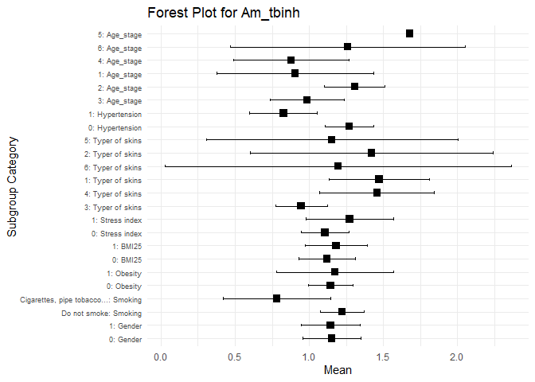

## Tạo bảng và Forest plot với biến Ar_tbinh

| Subgroup_Category | Subgroup | n_Ar_tbinh | Mean | CI_lower | CI_upper | P_Value |
| --- | --- | --- | --- | --- | --- | --- |
| Gender | 0 | 31 | 0.7059005 | 0.6130199 | 0.7987812 | 0.8045389 |
| Gender | 1 | 44 | 0.6693902 | 0.5825569 | 0.7562234 | 0.8045389 |
| Smoking | Do not smoke | 62 | 0.7187540 | 0.6532557 | 0.7842524 | 0.0289921 |
| Smoking | Cigarettes, pipe tobacco… | 13 | 0.5210256 | 0.3485531 | 0.6934982 | 0.0289921 |
| Obesity | 0 | 68 | 0.6861887 | 0.6179663 | 0.7544112 | 0.9274360 |
| Obesity | 1 | 7 | 0.6678929 | 0.5313220 | 0.8044637 | 0.9274360 |
| BMI25 | 0 | 42 | 0.6491071 | 0.5622380 | 0.7359763 | 0.2424766 |
| BMI25 | 1 | 33 | 0.7295025 | 0.6375945 | 0.8214106 | 0.2424766 |
| Stress index | 0 | 57 | 0.6597339 | 0.5838441 | 0.7356238 | 0.1483653 |
| Stress index | 1 | 18 | 0.7628472 | 0.6598725 | 0.8658219 | 0.1483653 |
| Typer of skins | 3 | 40 | 0.5681667 | 0.4941772 | 0.6421561 | NA |
| Typer of skins | 4 | 11 | 0.8965152 | 0.7351162 | 1.0579141 | NA |
| Typer of skins | 1 | 10 | 0.8005250 | 0.6268800 | 0.9741700 | NA |
| Typer of skins | 6 | 4 | 0.7225000 | 0.4618841 | 0.9831159 | NA |
| Typer of skins | 2 | 4 | 0.8087500 | 0.3881844 | 1.2293156 | NA |
| Typer of skins | 5 | 6 | 0.7695833 | 0.3799776 | 1.1591891 | NA |
| Hypertension | 0 | 54 | 0.7375154 | 0.6675938 | 0.8074371 | 0.0052567 |
| Hypertension | 1 | 21 | 0.5481071 | 0.4261820 | 0.6700323 | 0.0052567 |
| Age_stage | 3 | 13 | 0.6160769 | 0.4809776 | 0.7511762 | NA |
| Age_stage | 2 | 36 | 0.7370486 | 0.6526069 | 0.8214903 | NA |
| Age_stage | 1 | 7 | 0.5567857 | 0.3437836 | 0.7697879 | NA |
| Age_stage | 4 | 12 | 0.5936111 | 0.3804621 | 0.8067601 | NA |
| Age_stage | 6 | 6 | 0.8145833 | 0.4497840 | 1.1793827 | NA |
| Age_stage | 5 | 1 | 0.8850000 | NaN | NaN | NA |

Wilcox pairwise test cho các sub group có >2 level

```
## Group Gender does not have more than 2 unique levels. Skipping.
```

```
## Group Smoking does not have more than 2 unique levels. Skipping.
```

```
## Group Obesity does not have more than 2 unique levels. Skipping.
```

```
## Group BMI25 does not have more than 2 unique levels. Skipping.
```

```
## Group Stress index does not have more than 2 unique levels. Skipping.
```

```
## Group Hypertension does not have more than 2 unique levels. Skipping.
```

| Group | Group1 | Group2 | P_Value |
| --- | --- | --- | --- |
| Typer of skins | 3 | 4 | 0.0008256 |
| Typer of skins | 3 | 1 | 0.0105012 |
| Typer of skins | 3 | 6 | 0.1913715 |
| Typer of skins | 3 | 2 | 0.0982010 |
| Typer of skins | 3 | 5 | 0.1758435 |
| Typer of skins | 4 | 1 | 0.3866794 |
| Typer of skins | 4 | 6 | 0.2256410 |
| Typer of skins | 4 | 2 | 0.4893773 |
| Typer of skins | 4 | 5 | 0.6150858 |
| Typer of skins | 1 | 6 | 0.7332667 |
| Typer of skins | 1 | 2 | 0.9450549 |
| Typer of skins | 1 | 5 | 1.0000000 |
| Typer of skins | 6 | 2 | 0.6857143 |
| Typer of skins | 6 | 5 | 0.6095238 |
| Typer of skins | 2 | 5 | 0.9142857 |
| Age_stage | 3 | 2 | 0.1155001 |
| Age_stage | 3 | 1 | 0.7212961 |
| Age_stage | 3 | 4 | 0.7440117 |
| Age_stage | 3 | 6 | 0.1791243 |
| Age_stage | 3 | 5 | 0.2857143 |
| Age_stage | 2 | 1 | 0.0871054 |
| Age_stage | 2 | 4 | 0.1106300 |
| Age_stage | 2 | 6 | 0.5060360 |
| Age_stage | 2 | 5 | 0.6064250 |
| Age_stage | 1 | 4 | 0.9326171 |
| Age_stage | 1 | 6 | 0.2948718 |
| Age_stage | 1 | 5 | 0.5000000 |
| Age_stage | 4 | 6 | 0.1797027 |
| Age_stage | 4 | 5 | 0.6153846 |
| Age_stage | 6 | 5 | 0.8571429 |

Forest plot

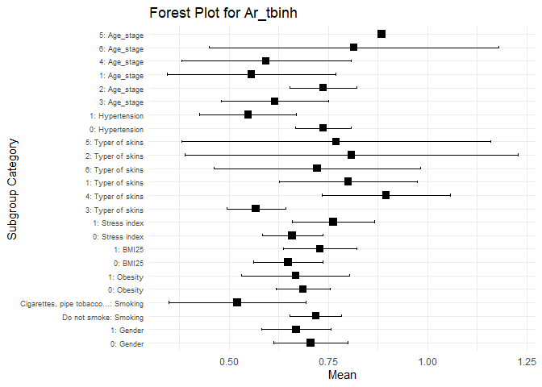

## Tạo bảng và Forest plot với biến Ac_tbinh

| Subgroup_Category | Subgroup | n_Ac_tbinh | Mean | CI_lower | CI_upper | P_Value |
| --- | --- | --- | --- | --- | --- | --- |
| Gender | 0 | 31 | 0.9259946 | 0.7878081 | 1.0641812 | 0.8590907 |
| Gender | 1 | 44 | 0.9097803 | 0.7943943 | 1.0251663 | 0.8590907 |
| Smoking | Do not smoke | 62 | 0.9519462 | 0.8589339 | 1.0449585 | 0.1378962 |
| Smoking | Cigarettes, pipe tobacco… | 13 | 0.7473462 | 0.5117796 | 0.9829127 | 0.1378962 |
| Obesity | 0 | 68 | 0.9137819 | 0.8206184 | 1.0069453 | 0.6293369 |
| Obesity | 1 | 7 | 0.9427143 | 0.6690105 | 1.2164181 | 0.6293369 |
| BMI25 | 0 | 42 | 0.8732063 | 0.7541119 | 0.9923008 | 0.3030014 |
| BMI25 | 1 | 33 | 0.9715606 | 0.8417447 | 1.1013765 | 0.3030014 |
| Stress index | 0 | 57 | 0.8914532 | 0.7872559 | 0.9956506 | 0.1704238 |
| Stress index | 1 | 18 | 0.9957407 | 0.8398063 | 1.1516752 | 0.1704238 |
| Typer of skins | 3 | 40 | 0.7970542 | 0.6808958 | 0.9132125 | NA |
| Typer of skins | 4 | 11 | 1.1309848 | 0.8868900 | 1.3750797 | NA |
| Typer of skins | 1 | 10 | 1.1488167 | 0.9114501 | 1.3861833 | NA |
| Typer of skins | 6 | 4 | 1.0925000 | 0.3877809 | 1.7972191 | NA |
| Typer of skins | 2 | 4 | 0.8400000 | 0.7228891 | 0.9571109 | NA |
| Typer of skins | 5 | 6 | 0.8658333 | 0.4973086 | 1.2343581 | NA |
| Hypertension | 0 | 54 | 0.9848549 | 0.8883551 | 1.0813548 | 0.0018748 |
| Hypertension | 1 | 21 | 0.7406667 | 0.5664419 | 0.9148914 | 0.0018748 |
| Age_stage | 3 | 13 | 0.8318462 | 0.7235725 | 0.9401198 | NA |
| Age_stage | 2 | 36 | 1.0081944 | 0.8760907 | 1.1402982 | NA |
| Age_stage | 1 | 7 | 0.6185714 | 0.4635169 | 0.7736260 | NA |
| Age_stage | 4 | 12 | 0.8054583 | 0.5073044 | 1.1036123 | NA |
| Age_stage | 6 | 6 | 1.0769444 | 0.6675533 | 1.4863356 | NA |
| Age_stage | 5 | 1 | 1.1700000 | NaN | NaN | NA |

Wilcox pairwise test cho các sub group có >2 level

```
## Group Gender does not have more than 2 unique levels. Skipping.
```

```
## Group Smoking does not have more than 2 unique levels. Skipping.
```

```
## Group Obesity does not have more than 2 unique levels. Skipping.
```

```
## Group BMI25 does not have more than 2 unique levels. Skipping.
```

```
## Group Stress index does not have more than 2 unique levels. Skipping.
```

```
## Group Hypertension does not have more than 2 unique levels. Skipping.
```

| Group | Group1 | Group2 | P_Value |
| --- | --- | --- | --- |
| Typer of skins | 3 | 4 | 0.0050221 |
| Typer of skins | 3 | 1 | 0.0068401 |
| Typer of skins | 3 | 6 | 0.1589518 |
| Typer of skins | 3 | 2 | 0.5815011 |
| Typer of skins | 3 | 5 | 0.5904249 |
| Typer of skins | 4 | 1 | 0.9719040 |
| Typer of skins | 4 | 6 | 0.9494505 |
| Typer of skins | 4 | 2 | 0.1040293 |
| Typer of skins | 4 | 5 | 0.0982547 |
| Typer of skins | 1 | 6 | 0.9435661 |
| Typer of skins | 1 | 2 | 0.0559674 |
| Typer of skins | 1 | 5 | 0.1748405 |
| Typer of skins | 6 | 2 | 0.4857143 |
| Typer of skins | 6 | 5 | 0.3923303 |
| Typer of skins | 2 | 5 | 0.7619048 |
| Age_stage | 3 | 2 | 0.1536543 |
| Age_stage | 3 | 1 | 0.0369453 |
| Age_stage | 3 | 4 | 0.5382455 |
| Age_stage | 3 | 6 | 0.2440660 |
| Age_stage | 3 | 5 | 0.2857143 |
| Age_stage | 2 | 1 | 0.0084882 |
| Age_stage | 2 | 4 | 0.1709728 |
| Age_stage | 2 | 6 | 0.7462980 |
| Age_stage | 2 | 5 | 0.6733983 |
| Age_stage | 1 | 4 | 0.3978177 |
| Age_stage | 1 | 6 | 0.0081585 |
| Age_stage | 1 | 5 | 0.2500000 |
| Age_stage | 4 | 6 | 0.1797027 |
| Age_stage | 4 | 5 | 0.4615385 |
| Age_stage | 6 | 5 | 0.5714286 |

Forest plot

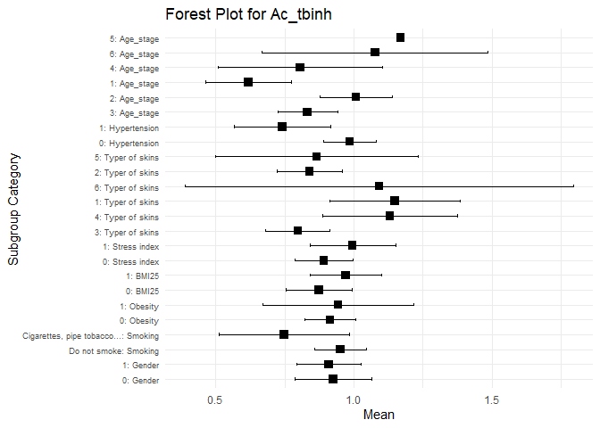

## Tạo bảng và Forest plot với biến F_Ae_tbinh

| Subgroup_Category | Subgroup | n_F_Ae_tbinh | Mean | CI_lower | CI_upper | P_Value |
| --- | --- | --- | --- | --- | --- | --- |
| Gender | 0 | 31 | 0.0148831 | 0.0139199 | 0.0158462 | 0.6744045 |
| Gender | 1 | 44 | 0.0150795 | 0.0142675 | 0.0158916 | 0.6744045 |
| Smoking | Do not smoke | 62 | 0.0148466 | 0.0141582 | 0.0155351 | 0.2805786 |
| Smoking | Cigarettes, pipe tobacco… | 13 | 0.0157218 | 0.0143959 | 0.0170476 | 0.2805786 |
| Obesity | 0 | 68 | 0.0149689 | 0.0143184 | 0.0156193 | 0.7985004 |
| Obesity | 1 | 7 | 0.0152845 | 0.0132233 | 0.0173458 | 0.7985004 |
| BMI25 | 0 | 42 | 0.0149060 | 0.0141411 | 0.0156708 | 0.7729423 |
| BMI25 | 1 | 33 | 0.0151159 | 0.0140926 | 0.0161392 | 0.7729423 |
| Stress index | 0 | 57 | 0.0150453 | 0.0143564 | 0.0157343 | 0.6193211 |
| Stress index | 1 | 18 | 0.0148495 | 0.0134418 | 0.0162573 | 0.6193211 |
| Typer of skins | 3 | 40 | 0.0147700 | 0.0138326 | 0.0157074 | NA |
| Typer of skins | 4 | 11 | 0.0145909 | 0.0128975 | 0.0162843 | NA |
| Typer of skins | 1 | 10 | 0.0158075 | 0.0145603 | 0.0170547 | NA |
| Typer of skins | 6 | 4 | 0.0141250 | 0.0111216 | 0.0171284 | NA |
| Typer of skins | 2 | 4 | 0.0172500 | 0.0123241 | 0.0221759 | NA |
| Typer of skins | 5 | 6 | 0.0150000 | 0.0131748 | 0.0168252 | NA |
| Hypertension | 0 | 54 | 0.0150704 | 0.0143480 | 0.0157928 | 0.7767645 |
| Hypertension | 1 | 21 | 0.0148131 | 0.0136000 | 0.0160262 | 0.7767645 |
| Age_stage | 3 | 13 | 0.0146308 | 0.0130803 | 0.0161812 | NA |
| Age_stage | 2 | 36 | 0.0153414 | 0.0144404 | 0.0162425 | NA |
| Age_stage | 1 | 7 | 0.0130357 | 0.0112526 | 0.0148188 | NA |
| Age_stage | 4 | 12 | 0.0151986 | 0.0132919 | 0.0171053 | NA |
| Age_stage | 6 | 6 | 0.0157083 | 0.0131799 | 0.0182368 | NA |
| Age_stage | 5 | 1 | 0.0145000 | NaN | NaN | NA |

Wilcox pairwise test cho các sub group có >2 level

```
## Group Gender does not have more than 2 unique levels. Skipping.
```

```
## Group Smoking does not have more than 2 unique levels. Skipping.
```

```
## Group Obesity does not have more than 2 unique levels. Skipping.
```

```
## Group BMI25 does not have more than 2 unique levels. Skipping.
```

```
## Group Stress index does not have more than 2 unique levels. Skipping.
```

```
## Group Hypertension does not have more than 2 unique levels. Skipping.
```

| Group | Group1 | Group2 | P_Value |
| --- | --- | --- | --- |
| Typer of skins | 3 | 4 | 0.7136218 |
| Typer of skins | 3 | 1 | 0.2743768 |
| Typer of skins | 3 | 6 | 0.7280117 |
| Typer of skins | 3 | 2 | 0.1350493 |
| Typer of skins | 3 | 5 | 0.8316975 |
| Typer of skins | 4 | 1 | 0.2161845 |
| Typer of skins | 4 | 6 | 0.8958470 |
| Typer of skins | 4 | 2 | 0.1162030 |
| Typer of skins | 4 | 5 | 0.6139967 |
| Typer of skins | 1 | 6 | 0.1371314 |
| Typer of skins | 1 | 2 | 0.2288198 |
| Typer of skins | 1 | 5 | 0.3551334 |
| Typer of skins | 6 | 2 | 0.2000000 |
| Typer of skins | 6 | 5 | 0.3923303 |
| Typer of skins | 2 | 5 | 0.1994576 |
| Age_stage | 3 | 2 | 0.3821812 |
| Age_stage | 3 | 1 | 0.1766317 |
| Age_stage | 3 | 4 | 0.8275017 |
| Age_stage | 3 | 6 | 0.2910981 |
| Age_stage | 3 | 5 | 1.0000000 |
| Age_stage | 2 | 1 | 0.0408029 |
| Age_stage | 2 | 4 | 0.8207037 |
| Age_stage | 2 | 6 | 0.6009771 |
| Age_stage | 2 | 5 | 0.8141997 |
| Age_stage | 1 | 4 | 0.0984520 |
| Age_stage | 1 | 6 | 0.0531265 |
| Age_stage | 1 | 5 | 1.0000000 |
| Age_stage | 4 | 6 | 0.7785063 |
| Age_stage | 4 | 5 | 1.0000000 |
| Age_stage | 6 | 5 | 0.8571429 |

Forest plot

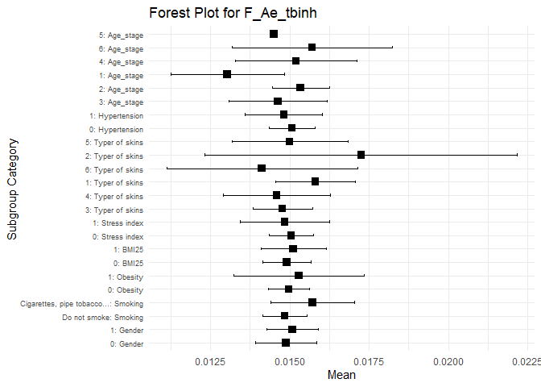

## Tạo bảng và Forest plot với biến F_An_tbinh

| Subgroup_Category | Subgroup | n_F_An_tbinh | Mean | CI_lower | CI_upper | P_Value |
| --- | --- | --- | --- | --- | --- | --- |
| Gender | 0 | 31 | 0.0340309 | 0.0307334 | 0.0373284 | 0.5830563 |
| Gender | 1 | 44 | 0.0343939 | 0.0319132 | 0.0368747 | 0.5830563 |
| Smoking | Do not smoke | 62 | 0.0340864 | 0.0319132 | 0.0362596 | 0.5802153 |
| Smoking | Cigarettes, pipe tobacco… | 13 | 0.0349949 | 0.0300183 | 0.0399714 | 0.5802153 |
| Obesity | 0 | 68 | 0.0343900 | 0.0323521 | 0.0364278 | 0.5060324 |
| Obesity | 1 | 7 | 0.0328250 | 0.0241704 | 0.0414796 | 0.5060324 |
| BMI25 | 0 | 42 | 0.0338635 | 0.0312659 | 0.0364610 | 0.6499777 |
| BMI25 | 1 | 33 | 0.0347280 | 0.0316398 | 0.0378162 | 0.6499777 |
| Stress index | 0 | 57 | 0.0335980 | 0.0315011 | 0.0356948 | 0.3147899 |
| Stress index | 1 | 18 | 0.0362894 | 0.0313259 | 0.0412528 | 0.3147899 |
| Typer of skins | 3 | 40 | 0.0336067 | 0.0308605 | 0.0363529 | NA |
| Typer of skins | 4 | 11 | 0.0366364 | 0.0299522 | 0.0433205 | NA |
| Typer of skins | 1 | 10 | 0.0305025 | 0.0276740 | 0.0333310 | NA |
| Typer of skins | 6 | 4 | 0.0390000 | 0.0311238 | 0.0468762 | NA |
| Typer of skins | 2 | 4 | 0.0333750 | 0.0121119 | 0.0546381 | NA |
| Typer of skins | 5 | 6 | 0.0377500 | 0.0297853 | 0.0457147 | NA |
| Hypertension | 0 | 54 | 0.0344586 | 0.0321910 | 0.0367262 | 0.7724222 |
| Hypertension | 1 | 21 | 0.0336917 | 0.0295912 | 0.0377921 | 0.7724222 |
| Age_stage | 3 | 13 | 0.0307808 | 0.0247619 | 0.0367997 | NA |
| Age_stage | 2 | 36 | 0.0349711 | 0.0324739 | 0.0374683 | NA |
| Age_stage | 1 | 7 | 0.0399286 | 0.0302759 | 0.0495812 | NA |
| Age_stage | 4 | 12 | 0.0309111 | 0.0261402 | 0.0356820 | NA |
| Age_stage | 6 | 6 | 0.0366250 | 0.0281256 | 0.0451244 | NA |
| Age_stage | 5 | 1 | 0.0390000 | NaN | NaN | NA |

Wilcox pairwise test cho các sub group có >2 level

```
## Group Gender does not have more than 2 unique levels. Skipping.
```

```
## Group Smoking does not have more than 2 unique levels. Skipping.
```

```
## Group Obesity does not have more than 2 unique levels. Skipping.
```

```
## Group BMI25 does not have more than 2 unique levels. Skipping.
```

```
## Group Stress index does not have more than 2 unique levels. Skipping.
```

```
## Group Hypertension does not have more than 2 unique levels. Skipping.
```

| Group | Group1 | Group2 | P_Value |
| --- | --- | --- | --- |
| Typer of skins | 3 | 4 | 0.4565341 |
| Typer of skins | 3 | 1 | 0.3318129 |
| Typer of skins | 3 | 6 | 0.1413499 |
| Typer of skins | 3 | 2 | 1.0000000 |
| Typer of skins | 3 | 5 | 0.2150190 |
| Typer of skins | 4 | 1 | 0.2048217 |
| Typer of skins | 4 | 6 | 0.4715241 |
| Typer of skins | 4 | 2 | 0.6011831 |
| Typer of skins | 4 | 5 | 0.8075307 |
| Typer of skins | 1 | 6 | 0.0159760 |
| Typer of skins | 1 | 2 | 1.0000000 |
| Typer of skins | 1 | 5 | 0.0824364 |
| Typer of skins | 6 | 2 | 0.6631172 |
| Typer of skins | 6 | 5 | 0.9148486 |
| Typer of skins | 2 | 5 | 0.7619048 |
| Age_stage | 3 | 2 | 0.0753604 |
| Age_stage | 3 | 1 | 0.0369453 |
| Age_stage | 3 | 4 | 0.6436468 |
| Age_stage | 3 | 6 | 0.2032693 |
| Age_stage | 3 | 5 | 0.4285714 |
| Age_stage | 2 | 1 | 0.4295688 |
| Age_stage | 2 | 4 | 0.0977905 |
| Age_stage | 2 | 6 | 0.5529183 |
| Age_stage | 2 | 5 | 0.6731975 |
| Age_stage | 1 | 4 | 0.0906854 |
| Age_stage | 1 | 6 | 0.6673748 |
| Age_stage | 1 | 5 | 0.8262384 |
| Age_stage | 4 | 6 | 0.1212930 |
| Age_stage | 4 | 5 | 0.4213995 |
| Age_stage | 6 | 5 | 1.0000000 |

Forest plot

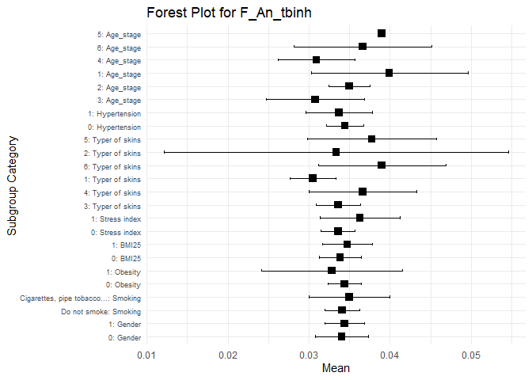

## Tạo bảng và Forest plot với biến F_Am_tbinh

| Subgroup_Category | Subgroup | n_F_Am_tbinh | Mean | CI_lower | CI_upper | P_Value |
| --- | --- | --- | --- | --- | --- | --- |
| Gender | 0 | 31 | 0.0825685 | 0.0732870 | 0.0918501 | 0.8501546 |
| Gender | 1 | 44 | 0.0815542 | 0.0743143 | 0.0887940 | 0.8501546 |
| Smoking | Do not smoke | 62 | 0.0795577 | 0.0738034 | 0.0853119 | 0.1141254 |
| Smoking | Cigarettes, pipe tobacco… | 13 | 0.0934949 | 0.0758723 | 0.1111174 | 0.1141254 |
| Obesity | 0 | 68 | 0.0827913 | 0.0767270 | 0.0888556 | 0.6152809 |
| Obesity | 1 | 7 | 0.0740286 | 0.0616901 | 0.0863670 | 0.6152809 |
| BMI25 | 0 | 42 | 0.0844270 | 0.0762856 | 0.0925684 | 0.3798477 |
| BMI25 | 1 | 33 | 0.0788508 | 0.0711606 | 0.0865409 | 0.3798477 |
| Stress index | 0 | 57 | 0.0835038 | 0.0767735 | 0.0902341 | 0.4975312 |
| Stress index | 1 | 18 | 0.0771273 | 0.0670184 | 0.0872362 | 0.4975312 |
| Typer of skins | 3 | 40 | 0.0845358 | 0.0765351 | 0.0925366 | NA |
| Typer of skins | 4 | 11 | 0.0770038 | 0.0636478 | 0.0903598 | NA |
| Typer of skins | 1 | 10 | 0.0762783 | 0.0619925 | 0.0905641 | NA |
| Typer of skins | 6 | 4 | 0.0830000 | 0.0192815 | 0.1467185 | NA |
| Typer of skins | 2 | 4 | 0.0706250 | 0.0415634 | 0.0996866 | NA |
| Typer of skins | 5 | 6 | 0.0903750 | 0.0605113 | 0.1202387 | NA |
| Hypertension | 0 | 54 | 0.0799640 | 0.0738435 | 0.0860846 | 0.5303264 |
| Hypertension | 1 | 21 | 0.0871405 | 0.0741926 | 0.1000883 | 0.5303264 |
| Age_stage | 3 | 13 | 0.0799192 | 0.0639095 | 0.0959290 | NA |
| Age_stage | 2 | 36 | 0.0830775 | 0.0742256 | 0.0919295 | NA |
| Age_stage | 1 | 7 | 0.0777500 | 0.0647836 | 0.0907164 | NA |
| Age_stage | 4 | 12 | 0.0826194 | 0.0684654 | 0.0967734 | NA |
| Age_stage | 6 | 6 | 0.0866806 | 0.0575458 | 0.1158153 | NA |
| Age_stage | 5 | 1 | 0.0625000 | NaN | NaN | NA |

Wilcox pairwise test cho các sub group có >2 level

```
## Group Gender does not have more than 2 unique levels. Skipping.
```

```
## Group Smoking does not have more than 2 unique levels. Skipping.
```

```
## Group Obesity does not have more than 2 unique levels. Skipping.
```

```
## Group BMI25 does not have more than 2 unique levels. Skipping.
```

```
## Group Stress index does not have more than 2 unique levels. Skipping.
```

```
## Group Hypertension does not have more than 2 unique levels. Skipping.
```

| Group | Group1 | Group2 | P_Value |
| --- | --- | --- | --- |
| Typer of skins | 3 | 4 | 0.3458901 |
| Typer of skins | 3 | 1 | 0.4295349 |
| Typer of skins | 3 | 6 | 0.4239510 |
| Typer of skins | 3 | 2 | 0.1819486 |
| Typer of skins | 3 | 5 | 0.6349394 |
| Typer of skins | 4 | 1 | 1.0000000 |
| Typer of skins | 4 | 6 | 0.6465253 |
| Typer of skins | 4 | 2 | 0.3559978 |
| Typer of skins | 4 | 5 | 0.3917856 |
| Typer of skins | 1 | 6 | 0.6194608 |
| Typer of skins | 1 | 2 | 0.2015990 |
| Typer of skins | 1 | 5 | 0.3024573 |
| Typer of skins | 6 | 2 | 0.5516159 |
| Typer of skins | 6 | 5 | 0.5211659 |
| Typer of skins | 2 | 5 | 0.2351956 |
| Age_stage | 3 | 2 | 0.5316621 |
| Age_stage | 3 | 1 | 0.7494369 |
| Age_stage | 3 | 4 | 0.3124186 |
| Age_stage | 3 | 6 | 0.4817441 |
| Age_stage | 3 | 5 | 0.7082810 |
| Age_stage | 2 | 1 | 1.0000000 |
| Age_stage | 2 | 4 | 0.5826924 |
| Age_stage | 2 | 6 | 0.8148311 |
| Age_stage | 2 | 5 | 0.3976702 |
| Age_stage | 1 | 4 | 0.9323201 |
| Age_stage | 1 | 6 | 0.8298633 |
| Age_stage | 1 | 5 | 0.6606202 |
| Age_stage | 4 | 6 | 1.0000000 |
| Age_stage | 4 | 5 | 0.3489119 |
| Age_stage | 6 | 5 | 0.2071963 |

Forest plot

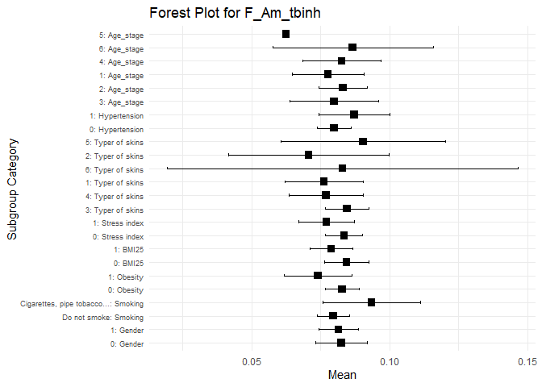

## Tạo bảng và Forest plot với biến F_Ar_tbinh

| Subgroup_Category | Subgroup | n_F_Ar_tbinh | Mean | CI_lower | CI_upper | P_Value |
| --- | --- | --- | --- | --- | --- | --- |
| Gender | 0 | 31 | 0.3212997 | 0.2808486 | 0.3617508 | 0.4175168 |
| Gender | 1 | 44 | 0.3334398 | 0.3027703 | 0.3641093 | 0.4175168 |
| Smoking | Do not smoke | 62 | 0.3221415 | 0.2956423 | 0.3486408 | 0.2431392 |
| Smoking | Cigarettes, pipe tobacco… | 13 | 0.3583744 | 0.2962534 | 0.4204953 | 0.2431392 |
| Obesity | 0 | 68 | 0.3232468 | 0.2982542 | 0.3482394 | 0.1938704 |
| Obesity | 1 | 7 | 0.3786940 | 0.2778777 | 0.4795104 | 0.1938704 |
| BMI25 | 0 | 42 | 0.3105702 | 0.2792590 | 0.3418815 | 0.0628063 |
| BMI25 | 1 | 33 | 0.3511422 | 0.3134932 | 0.3887911 | 0.0628063 |
| Stress index | 0 | 57 | 0.3206640 | 0.2953514 | 0.3459766 | 0.3403447 |
| Stress index | 1 | 18 | 0.3529884 | 0.2890345 | 0.4169424 | 0.3403447 |
| Typer of skins | 3 | 40 | 0.3295071 | 0.2970577 | 0.3619565 | NA |
| Typer of skins | 4 | 11 | 0.3235606 | 0.2326381 | 0.4144832 | NA |
| Typer of skins | 1 | 10 | 0.3081942 | 0.2506716 | 0.3657168 | NA |
| Typer of skins | 6 | 4 | 0.4010000 | 0.1702964 | 0.6317036 | NA |
| Typer of skins | 2 | 4 | 0.3685000 | 0.2013610 | 0.5356390 | NA |
| Typer of skins | 5 | 6 | 0.2887083 | 0.2148959 | 0.3625207 | NA |
| Hypertension | 0 | 54 | 0.3109281 | 0.2851092 | 0.3367470 | 0.0217884 |
| Hypertension | 1 | 21 | 0.3734060 | 0.3203359 | 0.4264760 | 0.0217884 |
| Age_stage | 3 | 13 | 0.3668577 | 0.3158246 | 0.4178908 | NA |
| Age_stage | 2 | 36 | 0.2920405 | 0.2581376 | 0.3259434 | NA |
| Age_stage | 1 | 7 | 0.3337857 | 0.2051876 | 0.4623839 | NA |
| Age_stage | 4 | 12 | 0.3757389 | 0.3132732 | 0.4382046 | NA |
| Age_stage | 6 | 6 | 0.3829444 | 0.3181712 | 0.4477177 | NA |
| Age_stage | 5 | 1 | 0.2060000 | NaN | NaN | NA |

Wilcox pairwise test cho các sub group có >2 level

```
## Group Gender does not have more than 2 unique levels. Skipping.
```

```
## Group Smoking does not have more than 2 unique levels. Skipping.
```

```
## Group Obesity does not have more than 2 unique levels. Skipping.
```

```
## Group BMI25 does not have more than 2 unique levels. Skipping.
```

```
## Group Stress index does not have more than 2 unique levels. Skipping.
```

```
## Group Hypertension does not have more than 2 unique levels. Skipping.
```

| Group | Group1 | Group2 | P_Value |
| --- | --- | --- | --- |
| Typer of skins | 3 | 4 | 0.7040141 |
| Typer of skins | 3 | 1 | 0.3114066 |
| Typer of skins | 3 | 6 | 0.3661353 |
| Typer of skins | 3 | 2 | 0.6366359 |
| Typer of skins | 3 | 5 | 0.4221199 |
| Typer of skins | 4 | 1 | 0.9432131 |
| Typer of skins | 4 | 6 | 0.5100891 |
| Typer of skins | 4 | 2 | 0.4309424 |
| Typer of skins | 4 | 5 | 0.9598232 |
| Typer of skins | 1 | 6 | 0.1980895 |
| Typer of skins | 1 | 2 | 0.2267622 |
| Typer of skins | 1 | 5 | 0.7856496 |
| Typer of skins | 6 | 2 | 0.8824201 |
| Typer of skins | 6 | 5 | 0.2849576 |
| Typer of skins | 2 | 5 | 0.1606425 |
| Age_stage | 3 | 2 | 0.0058952 |
| Age_stage | 3 | 1 | 0.3025723 |
| Age_stage | 3 | 4 | 0.7028987 |
| Age_stage | 3 | 6 | 0.9649447 |
| Age_stage | 3 | 5 | 0.1357781 |
| Age_stage | 2 | 1 | 0.2861224 |
| Age_stage | 2 | 4 | 0.0209213 |
| Age_stage | 2 | 6 | 0.0334122 |
| Age_stage | 2 | 5 | 0.2511571 |
| Age_stage | 1 | 4 | 0.3523309 |
| Age_stage | 1 | 6 | 0.3659674 |
| Age_stage | 1 | 5 | 0.2723606 |
| Age_stage | 4 | 6 | 1.0000000 |
| Age_stage | 4 | 5 | 0.1808490 |
| Age_stage | 6 | 5 | 0.2857143 |

Forest plot

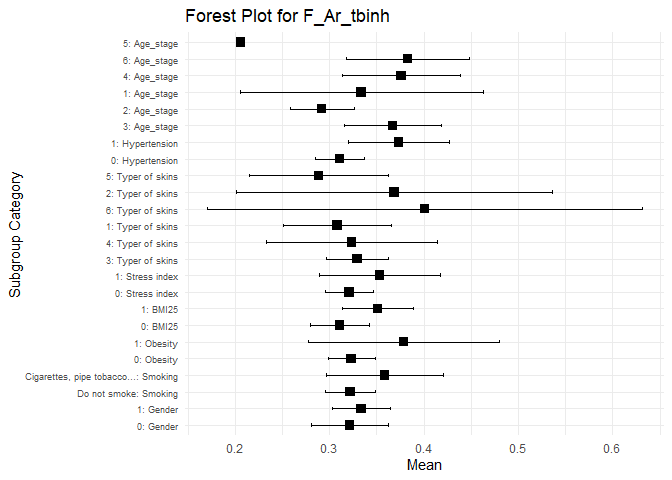

## Tạo bảng và Forest plot với biến F_Ac_tbinh

| Subgroup_Category | Subgroup | n_F_Ac_tbinh | Mean | CI_lower | CI_upper | P_Value |
| --- | --- | --- | --- | --- | --- | --- |
| Gender | 0 | 31 | 1.137913 | 1.0767083 | 1.199117 | 0.9313544 |
| Gender | 1 | 44 | 1.145394 | 1.0925260 | 1.198263 | 0.9313544 |
| Smoking | Do not smoke | 62 | 1.126991 | 1.0851290 | 1.168853 | 0.1832848 |
| Smoking | Cigarettes, pipe tobacco… | 13 | 1.215323 | 1.1056659 | 1.324980 | 0.1832848 |
| Obesity | 0 | 68 | 1.133314 | 1.0921700 | 1.174458 | 0.1374038 |
| Obesity | 1 | 7 | 1.229611 | 1.0874233 | 1.371798 | 0.1374038 |
| BMI25 | 0 | 42 | 1.139316 | 1.0824252 | 1.196207 | 0.5640621 |
| BMI25 | 1 | 33 | 1.146102 | 1.0911279 | 1.201076 | 0.5640621 |
| Stress index | 0 | 57 | 1.145189 | 1.0974135 | 1.192964 | 0.8231671 |
| Stress index | 1 | 18 | 1.133160 | 1.0650363 | 1.201283 | 0.8231671 |
| Typer of skins | 3 | 40 | 1.136161 | 1.0796270 | 1.192695 | NA |
| Typer of skins | 4 | 11 | 1.122053 | 1.0588435 | 1.185263 | NA |
| Typer of skins | 1 | 10 | 1.122086 | 0.9861229 | 1.258049 | NA |
| Typer of skins | 6 | 4 | 1.162750 | 0.9545646 | 1.370935 | NA |
| Typer of skins | 2 | 4 | 1.161500 | 1.0548623 | 1.268138 | NA |
| Typer of skins | 5 | 6 | 1.227625 | 0.9373798 | 1.517870 | NA |
| Hypertension | 0 | 54 | 1.129354 | 1.0879725 | 1.170736 | 0.1564526 |
| Hypertension | 1 | 21 | 1.175596 | 1.0797905 | 1.271402 | 0.1564526 |
| Age_stage | 3 | 13 | 1.203223 | 1.1368675 | 1.269579 | NA |
| Age_stage | 2 | 36 | 1.132075 | 1.0798465 | 1.184304 | NA |
| Age_stage | 1 | 7 | 1.171429 | 0.9363613 | 1.406496 | NA |
| Age_stage | 4 | 12 | 1.140975 | 1.0181191 | 1.263831 | NA |
| Age_stage | 6 | 6 | 1.026972 | 0.8094663 | 1.244478 | NA |
| Age_stage | 5 | 1 | 1.222500 | NaN | NaN | NA |

Wilcox pairwise test cho các sub group có >2 level

```
## Group Gender does not have more than 2 unique levels. Skipping.
```

```
## Group Smoking does not have more than 2 unique levels. Skipping.
```

```
## Group Obesity does not have more than 2 unique levels. Skipping.
```

```
## Group BMI25 does not have more than 2 unique levels. Skipping.
```

```
## Group Stress index does not have more than 2 unique levels. Skipping.
```

```
## Group Hypertension does not have more than 2 unique levels. Skipping.
```

| Group | Group1 | Group2 | P_Value |
| --- | --- | --- | --- |
| Typer of skins | 3 | 4 | 0.7135907 |
| Typer of skins | 3 | 1 | 0.8175200 |
| Typer of skins | 3 | 6 | 0.6675528 |
| Typer of skins | 3 | 2 | 0.9022763 |
| Typer of skins | 3 | 5 | 0.1968083 |
| Typer of skins | 4 | 1 | 0.5572642 |
| Typer of skins | 4 | 6 | 0.5135147 |
| Typer of skins | 4 | 2 | 0.6011831 |
| Typer of skins | 4 | 5 | 0.1801875 |
| Typer of skins | 1 | 6 | 0.7770588 |
| Typer of skins | 1 | 2 | 0.4535465 |
| Typer of skins | 1 | 5 | 0.3286159 |
| Typer of skins | 6 | 2 | 0.8857143 |
| Typer of skins | 6 | 5 | 0.4761905 |
| Typer of skins | 2 | 5 | 0.3523810 |
| Age_stage | 3 | 2 | 0.1563316 |
| Age_stage | 3 | 1 | 0.8119528 |
| Age_stage | 3 | 4 | 0.2742459 |
| Age_stage | 3 | 6 | 0.0350557 |
| Age_stage | 3 | 5 | 0.8036575 |
| Age_stage | 2 | 1 | 0.7795265 |
| Age_stage | 2 | 4 | 0.9904915 |
| Age_stage | 2 | 6 | 0.2724419 |
| Age_stage | 2 | 5 | 0.6729780 |
| Age_stage | 1 | 4 | 0.8322994 |
| Age_stage | 1 | 6 | 0.2948718 |
| Age_stage | 1 | 5 | 1.0000000 |
| Age_stage | 4 | 6 | 0.2219540 |
| Age_stage | 4 | 5 | 0.3462408 |
| Age_stage | 6 | 5 | 0.5714286 |

Forest plot

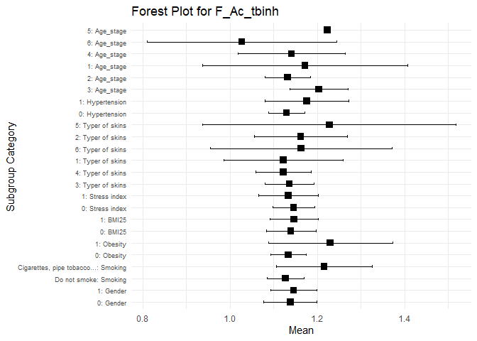